# positionmodeling

[figure not shown]

# Organizational & Position Projections

Accurately forecasting future headcount and position growth is critical for strategic planning, budgeting, and resource allocation. However, projecting organizational staffing needs is challenging because headcount is tied to broader business growth metrics, and different departments (such as customer service versus human resources) rely on entirely different operational drivers. Without a data-driven model, predicting future staffing requirements remains largely reactive rather than proactive.

This project establishes data-driven forecasting framework to predict future position totals through a structured multi-step approach:

- **Time Series & Regression Modeling:** Leveraging time series forecasting to predict future operational metrics, which are then fed into a regression model to project future staffing numbers.
- **Organizational Benchmarking:** Applying the same modeling pipeline to external organizational data to compare and contrast your company’s growth trends against industry standards.
- **Granular Departmental Breakdown:** Extending the model to specific job types within each group, tailoring unique, department-specific metrics (e.g., meter sets for customer service vs. miles of pipe for utility workers) to maximize prediction accuracy.

## Data

To support these projections, the models utilize a standardized set of organizational metrics commonly available across water utility companies. These metrics capture various operational and financial business metrics, providing a comprehensive foundation for both company-wide forecasting and industry benchmarking.

The data dictionary below outlines each metric used throughout this analysis:

```python
file_path = r"C:\Users\bpaton\Downloads\Organizational Projections Dataset.xlsx"

df_dict = pd.read_excel(file_path, sheet_name="Metric Dictionary")

create_html_table(df_dict)
```

| Field Name | Description | Source |
| --- | --- | --- |
| Year | Represents fiscal year end totals | nan |
| Total FTE | nan | nan |
| Gross Revenue | Total revenue reported during the fiscal year. | https://www.tohowater.com/about-us/annual-reports |
| Operating Expenses | Operating expenses reported on financial report during the fiscal year. | https://www.tohowater.com/about-us/annual-reports |
| Sales - Total | Total sales during the fiscal year. | https://www.tohowater.com/about-us/annual-reports |
| Meter Set | Number of meters placed during the fiscal year | https://www.tohowater.com/about-us/annual-reports |
| Capital Budget Annual - Water | Annual capital budget for water infrastructure | https://www.tohowater.com/about-us/annual-reports |
| Capital Budget Annual - WW | Annual capital budget for wastewater infrastructure | https://www.tohowater.com/about-us/annual-reports |
| Capital Budget Annual | Annual capital budget towards all infrastructure | https://www.tohowater.com/about-us/annual-reports |
| 5 Year Capital Budget | nan | https://www.tohowater.com/about-us/annual-reports |
| Capital Expenditure- Water | Annual capital expenditure for water infrastructure | https://www.tohowater.com/about-us/annual-reports |
| Capital Expenditure - WW | Annual capital expenditure for wastewater infrastructure | https://www.tohowater.com/about-us/annual-reports |
| Capital Expenditure Annual | Annual capital expenditure towards all infrastructure | https://www.tohowater.com/about-us/annual-reports |
| 5 Year Capital Spend - Water | Five year capital expenditure for water infrastructure | https://www.tohowater.com/about-us/annual-reports |
| 5 Year Capital Spend - WW2 | Five year capital expenditure for wastewater infrastructure | https://www.tohowater.com/about-us/annual-reports |
| 5 Year Capital Spend | Five year capital expenditure towards all infrastructure | https://www.tohowater.com/about-us/annual-reports |
| Water Facilities | Number of water facilities including plants and pump stations | https://www.tohowater.com/about-us/annual-reports |
| Wastewater Facilities | Number of wastewater treatment facilities | https://www.tohowater.com/about-us/annual-reports |
| Water Reclamation Facilities | Number of reclamation facilities | https://www.tohowater.com/about-us/annual-reports |
| Lift Stations | Number of lift stations | https://www.tohowater.com/about-us/annual-reports |
| Water - Raw (Mgal) | Total mega gallons of water pumped from water facilities during the year | https://www.tohowater.com/about-us/annual-reports |
| Water - Raw (Mgal) - Res | Total mega gallons of water pumped from water facilities for residential connections during the year | https://www.tohowater.com/about-us/annual-reports |
| Water - Raw (Mgal) - Commercial | Total mega gallons of water pumped from water facilities for commercial connections during the year | https://www.tohowater.com/about-us/annual-reports |
| Wastewater (Mgal) | Total mega gallons of wastewater treated during the year | https://www.tohowater.com/about-us/annual-reports |
| Wastewater (Mgal) Res | Total mega gallons of wastewater treated for residential connections during the year | https://www.tohowater.com/about-us/annual-reports |
| Wastewater (Mgal) Comm | Total mega gallons of wastewater treated for commercial connections during the year | https://www.tohowater.com/about-us/annual-reports |
| Reclaimed (Mgal) | Total mega gallons of water pumped from water facilities during the year | https://www.tohowater.com/about-us/annual-reports |
| Irrigation (Mgal) | Total mega gallons of water for irrigation connections during the year | https://www.tohowater.com/about-us/annual-reports |
| Connections | Total connections reported at fiscal year end | https://www.tohowater.com/about-us/annual-reports |
| Total Customers/Connections - Water | Total water connections reported at fiscal year end | https://www.tohowater.com/about-us/annual-reports |
| Total Customers/Connections - Water Res | Total residential water connections reported at fiscal year end | https://www.tohowater.com/about-us/annual-reports |
| Total Customers/Connections - Water Comm | Total commercial water connections reported at fiscal year end | https://www.tohowater.com/about-us/annual-reports |
| Total Customers/Connections - Irrigation | Total irrigation connections reported at fiscal year end | https://www.tohowater.com/about-us/annual-reports |
| Total Customers/Connections - WW | Total wastewater connections reported at fiscal year end | https://www.tohowater.com/about-us/annual-reports |
| Total Customers/Connections - WW Res | Total residential wastewater connections reported at fiscal year end | https://www.tohowater.com/about-us/annual-reports |
| Total Customers/Connections - WW Comm | Total commercial wastewater connections reported at fiscal year end | https://www.tohowater.com/about-us/annual-reports |
| Total Customers/Connections - Reclaimed | Total reclaimed connections reported at fiscal year end | https://www.tohowater.com/about-us/annual-reports |
| Population | Osceola County population as reported by BEBR. Totals for future dates are BEBR projections. | https://bebr.ufl.edu/ |
| Miles of Pipe - Water | Total miles of pipe use for water | nan |
| Miles of Gravity Main - Wastewater | total miles of wastewater gravity main pipe | nan |
| Miles of Force Main - Wastewater | total miles of wastewater force main pipe | nan |
| Miles of Pipe - Wastewater | total miles of wastewater pipe | nan |
| Permitted MGal | Total permitted megagallons of water allowed to be pumped | https://www.tohowater.com/about-us/annual-reports |
| Service Area Size (mi²) | service area size in square miles | nan |
| Total Osceola Parcels | total residebtial, commercial, agricultural, and vacant parcels in Osceola county. | https://www.property-appraiser.org/tax-rolls-statistics/ |
| Residential Parcels | Total residential parcels in Osceola county. | https://www.property-appraiser.org/tax-rolls-statistics/ |
| Commercial Parcels | Total commerical parcels in Osceola county. | https://www.property-appraiser.org/tax-rolls-statistics/ |
| Agriculture Parcels | Total agricultural parcels in Osceola county. | https://www.property-appraiser.org/tax-rolls-statistics/ |
| Vacant Parcels | Total vacant parcels in Osceola county. | https://www.property-appraiser.org/tax-rolls-statistics/ |

The table below shows the existing metric data collected for Toho.

```python
df_toho = pd.read_excel(file_path, sheet_name="Toho Metrics")

df_toho = df_toho.dropna(subset=['Year'])
df_toho = df_toho[df_toho['Year'] < 2026]

create_html_table(df_toho[['Year',
                          'Total FTE',
                          'Gross Revenue',
                          'Water - Raw (Mgal)',
                          'Wastewater (Mgal)',
                          'Total Customers/Connections - Water',
                          'Total Customers/Connections - WW',
                          'Population']])
```

| Year | Total FTE | Gross Revenue | Water - Raw (Mgal) | Wastewater (Mgal) | Total Customers/Connections - Water | Total Customers/Connections - WW | Population |
| --- | --- | --- | --- | --- | --- | --- | --- |
| 2025 | 695 | 244576 | 1.24478e+06 | 1.13561e+06 | 167323 | 163067 | 484915 |
| 2024 | 644 | 228952 | 1.17761e+06 | 1.07258e+06 | 159829 | 150097 | 465663 |
| 2023 | 618 | 203535 | 1.1831e+06 | 1.07275e+06 | 157425 | 146487 | 446411 |
| 2022 | 455.5 | 151647 | 957013 | 874497 | 121033 | 114780 | 427160 |
| 2021 | 423 | 141253 | 903186 | 830870 | 116719 | 105267 | 407908 |
| 2020 | 384.5 | 134534 | 860543 | 776941 | 112089 | 105757 | 388656 |
| 2019 | 365 | 130268 | 852322 | 782217 | 107798 | 101722 | 376659 |
| 2018 | 352 | 120133 | 816800 | 752210 | 103165 | 97181 | 364662 |
| 2017 | 339 | 112402 | 791105 | 709179 | 99939 | 94213 | 352665 |
| 2016 | 324 | 97725 | 782534 | 716930 | 96755 | 90816 | 340668 |
| 2015 | nan | 88232 | 751223 | 677193 | 93210 | 86820 | 328670 |
| 2014 | nan | 82379 | 730980 | 666284 | 90126 | 83826 | 316673 |
| 2013 | nan | 79873 | 716132 | 650768 | 87592 | 81448 | 304676 |
| 2012 | nan | 78761 | 723001 | 642722 | 85776 | 79259 | 292679 |
| 2011 | nan | 74877 | 0 | 0 | nan | 0 | 280682 |
| 2010 | nan | nan | 0 | 0 | nan | 0 | 268685 |
| 2009 | nan | nan | 0 | 0 | nan | 0 | nan |
| 2008 | nan | nan | 0 | 0 | nan | 0 | nan |
| 2007 | nan | nan | 0 | 0 | nan | 0 | nan |
| 2006 | nan | nan | 0 | 0 | nan | 0 | nan |
| 2005 | nan | nan | 0 | 0 | nan | 0 | nan |
| 2004 | nan | nan | 0 | 0 | nan | 0 | nan |

## Modeling

Our forecasting framework uses a three-step process to project future position needs:

- **Step 1: Relationship Mapping:** We will train a regression model on historical data to learn the relationship between our predictors and position count.
- **Step 2: Metric Projection:** We apply time series models to project our core operational predictors five years into the future.
- **Step 3: Position Projections:** Using the relationship learned by the regression model, we will predict future position needs based on the forecasted organizational metrics.

### Time Series Forecasting

Time series modeling is a statistical approach used to analyze sequential data collected over regular time intervals. By examining historical patterns, trends, and seasonal behaviors, these models project future outcomes based on past trajectories.

In this project, time series forecasting is applied to core organizational metrics, such as water production and revenue, to model the past trend and calculate values for future years.

#### Candidate Models for Evaluation

Three time series models that each have a different approach will be considered.

- **ARIMA (Autoregressive Integrated Moving Average):** Highly effective at capturing linear trends and time-dependent correlations in data. However, it can struggle with sudden structural shifts or incorporating external business drivers without manual adjustments.
- **Holt-Winters Exponential Smoothing:** Excellent for capturing data with distinct trend and seasonal components using an intuitive weighted-average approach. Its primary limitation is a lack of flexibility for incorporating custom external regressors like our 2022 Saint Cloud system acquisition.
- **Prophet:** Exceptionally flexible in handling missing data, outliers, and custom additive regressors making it ideal for incorporating our 2022 Saint Cloud system acquisition. However, its automated curve-fitting can occasionally risk overfitting smaller sample sizes if hyperparameter ranges are not strictly managed.

Through cross-validation evaluated via Root Mean Squared Error (RMSE), we determine which of these models delivers the most reliable, future-proof projections for our organization.

### Regression

To model organizational metrics alongside our time-series forecasts, we will use regression models.

$$\hat{y} = \beta_0 + \beta_1 x_1 + \beta_2 x_2 + \beta_3 x_3$$

Where:

- $\hat{y}$: The predicted value of the dependent variable - positions.
- $\beta_0$: The intercept (the baseline value when all predictors are zero).
- $\beta_1, \beta_2, \beta_3$: The regression coefficients that will be calculated using existing data
- $x_1, x_2, x_3$: Our three independent predictor variables (such as headcount, population, or water production).

Regression is used to model the relationship between a dependent variable (positions) and one or more independent variables (water production, population, revenue, etc.). These independent variables used to predict our dependent variable are known as predictors. Note that while the equation above shows an example using three predictors, a regression model is not restricted to a specific amount of predictors.

#### Choosing Predictors for Regression

Selecting the optimal combination of predictors is critical to building robust models without overfitting our relatively small sample size. To achieve this, we will use the same cross-validation technique used in our time-series evaluations. Rather than optimizing model hyperparameters, cross-validation is used to test different subsets of predictors.

For each candidate combination of predictors, the model’s performance is evaluated using Root Mean Squared Error (RMSE) via cross-validation. The set of predictors that yields the highest predictive performance (the lowest cross-validation RMSE) is established as our primary candidate for the final regression model.

While cross-validation will provide us with a combination of predictors, there may be instances where we deviate and use sub-optimal predictors according to the cross-validation process.

- When statistical optimization produces counter-intuitive relationships such as a negative correlation where common sense indicates it should be positive.
- When there may be an instance a subject matter expert recommends a certain metric is a driver.

Deviations will be explained in the appropriate section if applicable.

## Model Evaluation

Evaluating our models ensures that our projections for company growth and headcount are reliable rather than just memorizing past trends. Because our pipeline combines time series forecasting with regression, we need to use specific evaluation strategies tailored to each layer of the model.

### Time Series Evaluation

To evaluate how well our Prophet models forecast future operational metrics (like water produced or revenue), we use Time Series Cross-Validation.

- **How it works:** Instead of randomly shuffling data, this method steps forward in time. It trains the model on an initial historical window (for example, the first few years of data) and then evaluates its accuracy by predicting a subsequent horizon (like the next year). It repeats this process multiple times by sliding the training window forward across different historical checkpoints.
- **Why it works:** Time series data has a strict chronological order, meaning the future depends on the past. Traditional random data splitting would let the model “cheat” by training on future data to predict the past. Time series cross-validation mimics real-world forecasting by strictly testing the model’s ability to predict unseen future periods using only past information.
- **Scoring with RMSE:** As the sliding windows generate predictions across multiple future horizons, **Root Mean Squared Error (RMSE)** is calculated for each step (or averaged across all horizons) to score the overall forecasting accuracy, heavily penalizing larger prediction misses to ensure reliability over time.

### Regression Model Evaluation

To evaluate our regression models—which map operational metrics to future position totals—we must choose a validation technique that balances our need for accuracy with our limited data availability.

- **The Standard Approach (80/20 Split):** Typically, predictive models use an 80/20 train-test split. This means the model is trained on 80% of the historical data to learn the relationships between variables, and then tested against the remaining 20% of unseen data to check its performance.
- **Why an 80/20 Split Fails for Small Datasets:** When working with limited organizational history, holding back 20% of the data for testing leaves too few data points to train a stable, reliable model. Furthermore, discarding precious historical records for testing starves the model of the trends it needs to learn effectively.
- **How Leave-One-Out Cross-Validation (LOOCV) Solves This:** To overcome the limitations of small sample sizes, we use Leave-One-Out Cross-Validation (LOOCV). LOOCV takes a dataset of $N$ points, trains the model on $N-1$ of them, and tests it on the single remaining data point. It repeats this process $N$ times so every point gets tested, and averages the results. This maximizes data efficiency by allowing the model to train on nearly the entire dataset during every iteration.
- **Scoring with RMSE:** As the LOOCV loop iterates through each left-out data point, the model generates a prediction for that single point. **Root Mean Squared Error (RMSE)** is then calculated across all $N$ prediction errors to calculate a final overall scorecard, giving us a clear, interpretable measure of how accurately our regression model performs.

### Evaluating with Root Mean Squared Error (RMSE)

To measure and score how accurately our models perform during both Leave-One-Out Cross-Validation and Time Series Cross-Validation, we use **Root Mean Squared Error (RMSE)**. RMSE acts as the scorecard for our predictions, telling us, on average, how far off our model’s estimates are from actual historical figures.

RMSE is defined as:

$$RMSE = \sqrt{\frac{1}{n} \sum_{i=1}^{n} (y_i - \hat{y}_i)^2}$$

#### Variables:

- $n$: The total number of data points or predictions being evaluated.
- $y_i$: The actual, true value (e.g., your company’s true historical headcount or operational metric).
- $\hat{y}_i$: The predicted value generated by the model.
- $\sum$: The sum across all $n$ data points.

#### Why RMSE is Effective:

1. **Penalizes Large Errors:** Because the differences are squared ($(y_i - \hat{y}_i)^2$), larger misses are penalized much more heavily than small ones. This ensures the model prioritizes avoiding massive forecasting errors.
2. **Interpretable Units:** Taking the square root at the end brings the final error score back down to the original unit of measurement (such as water production in gallons), making it intuitive to understand and report.

## Position Regression Model

The primary goal of this section is to model the mathematical relationship between Total FTE and our selected water utility predictors. By establishing this relationship, we can project future staffing requirements and quantify uncertainty in the results.

Because organizational and utility metrics tend to scale together, multicollinearity presents a natural challenge for our model. In standard linear regression, high correlation between predictors can still calculate positions with reasonable accuracy, but it causes unstable coefficients with inflated standard errors making it difficult to see the true effects of each predictor.

To mitigate this, we will be using [ridge regression](https://library.virginia.edu/data/articles/addressing-multicollinearity) which introduces an $L_2$ regularization penalty that shrinks the coefficients and stabilizes the model.

```python
df_regression = df_toho.dropna(subset='Total FTE')
df_regression = df_regression[['Year',
  'Total FTE',
  'Gross Revenue',
  'Water - Raw (Mgal)',
  'Wastewater (Mgal)',
  'Total Customers/Connections - Water']]

create_html_table(df_regression)
```

| Year | Total FTE | Gross Revenue | Water - Raw (Mgal) | Wastewater (Mgal) | Total Customers/Connections - Water |
| --- | --- | --- | --- | --- | --- |
| 2025 | 695 | 244576 | 1.24478e+06 | 1.13561e+06 | 167323 |
| 2024 | 644 | 228952 | 1.17761e+06 | 1.07258e+06 | 159829 |
| 2023 | 618 | 203535 | 1.1831e+06 | 1.07275e+06 | 157425 |
| 2022 | 455.5 | 151647 | 957013 | 874497 | 121033 |
| 2021 | 423 | 141253 | 903186 | 830870 | 116719 |
| 2020 | 384.5 | 134534 | 860543 | 776941 | 112089 |
| 2019 | 365 | 130268 | 852322 | 782217 | 107798 |
| 2018 | 352 | 120133 | 816800 | 752210 | 103165 |
| 2017 | 339 | 112402 | 791105 | 709179 | 99939 |
| 2016 | 324 | 97725 | 782534 | 716930 | 96755 |

While high multicollinearity is expected, the correlation plot below shows visually how closely related the growth of each predictor is in relation to each other.

For this plot, a correlation coefficient of 1 means the two metrics are growing perfectly in sync with each other. Since each value is so close to 1, it confirms that it is critical to use ridge regression for the model opposed to standard regression because of the strong presence of multicollinearity.

```python
# Define predictor columns
predictors = [
    'Water - Raw (Mgal)',
    'Wastewater (Mgal)',
    'Total Customers/Connections - Water',
    'Gross Revenue'
]

corr_matrix = df_regression[predictors].corr()

plt.figure(figsize=(8, 6))
sns.set_theme(style="white")

sns.heatmap(
    corr_matrix,
    annot=True,
    fmt=".2f",
    cmap='coolwarm',
    vmin=-1,
    vmax=1,
    square=True,
    linewidths=.5,
    cbar_kws={"shrink": .8}
)

plt.title('Predictor Correlation Matrix (Multicollinearity Check)', fontsize=14, fontweight='bold', pad=15)
plt.xticks(rotation=45, ha='right')
```

```
(array([0.5, 1.5, 2.5, 3.5]), [Text(0.5, 0, 'Water - Raw (Mgal)'), Text(1.5, 0, 'Wastewater (Mgal)'), Text(2.5, 0, 'Total Customers/Connections - Water'), Text(3.5, 0, 'Gross Revenue')])
```

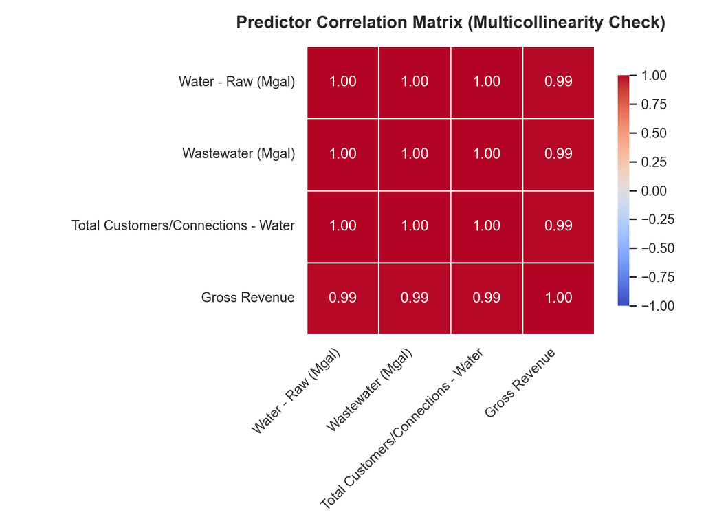

```python
plt.tight_layout()

# Display the plot
plt.show()
```

```python
plt.close()
```

The scatter plots below demonstrate the relationship between each individual predictor and Total FTE. The relationship for each variable appears to be linear. The large gap in the middle of each plot is the result from the large jump in each metric during the Saint Cloud infrastructure acquisition.

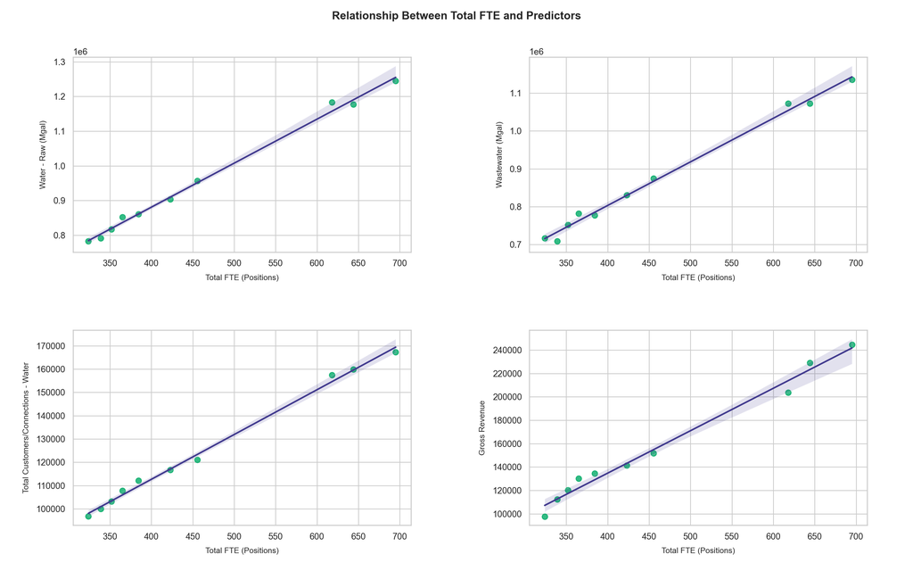

```python
sns.set_theme(style="whitegrid")

# Set up subplot grid
fig, axes = plt.subplots(nrows=2, ncols=2, figsize=(16, 10))
axes = axes.flatten()

# Loop through each predictor and create its respective scatter plot
for i, col in enumerate(predictors):
    ax = axes[i]

    sns.regplot(
        data=df_regression,
        x='Total FTE',
        y=col,
        ax=ax,
        color='#00AA65',
        marker='o',
        scatter_kws={'s': 50, 'alpha': 0.8},
        line_kws={'color': '#413A8E', 'linewidth': 2}
    )

    # Clear, well-spaced titles and labels
    ax.set_xlabel('Total FTE (Positions)', fontsize=10, labelpad=8)
    ax.set_ylabel(col, fontsize=10, labelpad=8)



plt.suptitle('Relationship Between Total FTE and Predictors', fontsize=14, fontweight='bold', y=0.98)

plt.subplots_adjust(left=0.08, right=0.95, top=0.90, bottom=0.08, wspace=0.35, hspace=0.40)

plt.show()
```

```python
plt.close()
```

#### Calculate Best Predictors

To choose which predictors will be used in the final model, cross-validation will be used where each combination of predictors will be used to train a model, evaluated using RMSE, and the result will be stored.

[output not shown]

The table below outlines the cross-validation performance across feature combinations. While the top-performing model achieved the lowest RMSE using a two-metric combination , the top 10 models exhibit little performance variation.

While this is the highest performing combination, there is low variation between the top 10 performing models. Since all of these combinations produce relatively accurate models, we will select a combination that will give future-proof results. Incorporating a more diverse set of predictors prevents the model from becoming overly reliant on any single influential metric, providing greater flexibility and resilience against future organizational shifts.

For this reason, we will proceeding with using Gross Revenue, Total Customers/Connections - Water, and Wastewater (Mgal).

```python
create_html_table(results_df.sort_values(by='RMSE Score', ascending = True))
```

| Predictor Combination | RMSE Score |
| --- | --- |
| ['Wastewater (Mgal)', 'Gross Revenue'] | 10.3 |
| ['Water - Raw (Mgal)', 'Gross Revenue'] | 10.9 |
| ['Wastewater (Mgal)', 'Total Customers/Connections - Water', 'Gross Revenue'] | 11.3 |
| ['Total Customers/Connections - Water'] | 11.7 |
| ['Water - Raw (Mgal)', 'Total Customers/Connections - Water'] | 12 |
| ['Water - Raw (Mgal)', 'Total Customers/Connections - Water', 'Gross Revenue'] | 12.1 |
| ['Wastewater (Mgal)', 'Total Customers/Connections - Water'] | 12.1 |
| ['Water - Raw (Mgal)', 'Wastewater (Mgal)', 'Gross Revenue'] | 12.6 |
| ['Water - Raw (Mgal)'] | 12.7 |
| ['Water - Raw (Mgal)', 'Wastewater (Mgal)', 'Total Customers/Connections - Water', 'Gross Revenue'] | 13.3 |
| ['Water - Raw (Mgal)', 'Wastewater (Mgal)', 'Total Customers/Connections - Water'] | 13.8 |
| ['Wastewater (Mgal)'] | 14.2 |
| ['Water - Raw (Mgal)', 'Wastewater (Mgal)'] | 14.3 |
| ['Total Customers/Connections - Water', 'Gross Revenue'] | 14.4 |
| ['Gross Revenue'] | 20.3 |

#### Train and Evaluate Model

The trained model is below with the evaluated results.

```python
combination = ['Wastewater (Mgal)',
                    'Total Customers/Connections - Water',
                    'Gross Revenue']

# split to xy
X = df_regression[combination]
y = df_regression['Total FTE']

# Train Bayesian Ridge Model
best_ridge = BayesianRidge()
best_ridge.fit(X, y)
```

```
BayesianRidge()
```

```python
# 3. Evaluate performance
y_pred = best_ridge.predict(X)
rmse = round(np.sqrt(mean_squared_error(y, y_pred)), 4)
r2 = r2_score(y, y_pred)

print(f"Root Mean Squared Error (RMSE): {rmse:.4f}\n")
```

```
Root Mean Squared Error (RMSE): 7.4326
```

```python
print(f"R-squared (R²): {r2:.4f}")
```

```
R-squared (R²): 0.9968
```

Given the scale of total organizational headcount, this low error margin demonstrates that the Bayesian Ridge model successfully captured the underlying mathematical relationship between our operational predictors and staffing needs.

#### Regression Model Results

The table below shows the coefficents, y-intercept, and calculated 95% confidence interval for each predictor.

```python
# Calculate 95% Credible Intervals for the coefficients
coef_stds = np.sqrt(np.diagonal(best_ridge.sigma_))
z_score = 1.96  # 95% confidence level

lower_bounds = best_ridge.coef_ - z_score * coef_stds
upper_bounds = best_ridge.coef_ + z_score * coef_stds

ridge_coefficients = pd.DataFrame({
    'Predictor': ['Intercept'] + list(combination),
    'Coefficient': [best_ridge.intercept_] + list(best_ridge.coef_ * 10000),
    'Lower 95%': [np.nan] + list(lower_bounds * 10000),
    'Upper 95%': [np.nan] + list(upper_bounds * 10000)
})

create_html_table(ridge_coefficients)
```

| Predictor | Coefficient | Lower 95% | Upper 95% |
| --- | --- | --- | --- |
| Intercept | -185.561 | nan | nan |
| Wastewater (Mgal) | 4.71863 | 1.71123 | 7.72602 |
| Total Customers/Connections - Water | 9.3309 | -9.62778 | 28.2896 |
| Gross Revenue | 7.54118 | 0.512842 | 14.5695 |

The equation below is the mathematical representation of Total FTE as a function of Wastewater (Mgal), Total Customers/Connections - Water, and Gross Revenue.

```python
from IPython.display import Markdown, display

coef_water = ridge_coefficients.loc[ridge_coefficients['Predictor'] == 'Wastewater (Mgal)', 'Coefficient'].values[0]
coef_rev = ridge_coefficients.loc[ridge_coefficients['Predictor'] == 'Gross Revenue', 'Coefficient'].values[0]
coef_ww = ridge_coefficients.loc[ridge_coefficients['Predictor'] == 'Total Customers/Connections - Water', 'Coefficient'].values[0]
intercept = ridge_coefficients.loc[ridge_coefficients['Predictor'] == 'Intercept', 'Coefficient'].values[0]

# Build LaTeX string
equation = f"""
$$
\\text{{Total FTE}} = {coef_ww:.2f} \\times \\text{{10,000 Wastewater (Mgal)}} + {coef_water:.2f} \\times \\text{{10,000 Water Connections}} + {coef_rev:.2f} \\times \\text{{10,000 Gross Revenue}} +   + {intercept:.2f}
$$
"""

# Render it in the document
display(Markdown(equation))
```

[output not shown]

#### Regression Model Visualization

  The visual below shows the actual FTE with an overlay for the predicted FTE and the confidence interval.

  The confidence interval area shaded with purple represents an area where the model is 95% certain the FTE count will fall based on the Wastewater (Mgal), Water Connections, and Gross Revenue for that year. Any value outside of the confidence interval would be considered an outlier.

  It is important to disinguish that this curve represents Toho’s past trend, and doesn’t necessarily mean these predicted values are “correct”.

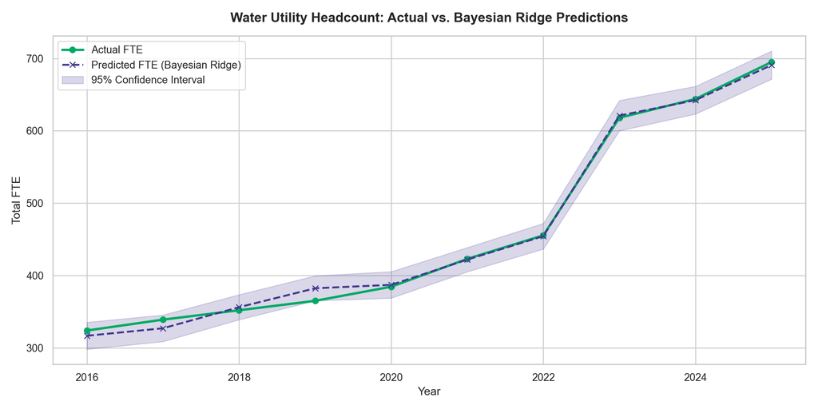

```python
X_all = df_regression[combination]

y_pred_mean, y_pred_std = best_ridge.predict(X_all, return_std=True)

z_score = 1.96
lower_bound = y_pred_mean - (z_score * y_pred_std)
upper_bound = y_pred_mean + (z_score * y_pred_std)

df_regression['Predicted FTE'] = y_pred_mean
df_regression['FTE_Lower_95'] = lower_bound
df_regression['FTE_Upper_95'] = upper_bound

output_columns = ['Year', 'Total FTE', 'Predicted FTE', 'FTE_Lower_95', 'FTE_Upper_95'] + list(combination)



df_regression = df_regression.sort_values('Year').reset_index(drop=True)

x_axis = df_regression['Year']

plt.figure(figsize=(12, 6))
sns.set_theme(style="whitegrid")

# Plot Actual FTE
plt.plot(
    x_axis,
    df_regression['Total FTE'],
    label='Actual FTE',
    color='#00AA65',
    marker='o',
    linewidth=2.5,
    markersize=6
)

# Plot Predicted FTE (Bayesian Ridge)
plt.plot(
    x_axis,
    df_regression['Predicted FTE'],
    label='Predicted FTE (Bayesian Ridge)',
    color='#413A8E',
    linestyle='--',
    marker='x',
    linewidth=2,
    markersize=6
)

# Add the 95% Confidence Interval
plt.fill_between(
    x_axis,
    df_regression['FTE_Lower_95'],
    df_regression['FTE_Upper_95'],
    color='#413A8E',
    alpha=0.2,
    label='95% Confidence Interval'
)

# 6. Chart Labels and Formatting
plt.title('Water Utility Headcount: Actual vs. Bayesian Ridge Predictions', fontsize=14, fontweight='bold', pad=15)
plt.xlabel('Year', fontsize=12)
plt.ylabel('Total FTE', fontsize=12)

plt.gca().xaxis.set_major_formatter(plt.FormatStrFormatter('%d'))

plt.legend(frameon=True, facecolor='white', loc='best')
plt.tight_layout()

plt.show()
```

```python
plt.close()
```

## Toho Metric Time Series Projections

The data set below consists of 10-15 years of metrics from Toho Water Authority that are defined by the previously stated data dictionary. Displayed are the metrics determined to be predictors by the regression model.

```python
df_toho['ds'] = df_toho['Year'].astype(int).apply(lambda y: pd.Timestamp(date(y, 9, 30)))

df_toho['acquisition_effect'] = (df_toho['Year'] >= 2023).astype(int)

create_html_table(df_toho[['Year',
  'Gross Revenue',
  'Water - Raw (Mgal)',
  'Wastewater (Mgal)',
  'Total Customers/Connections - Water']])
```

| Year | Gross Revenue | Water - Raw (Mgal) | Wastewater (Mgal) | Total Customers/Connections - Water |
| --- | --- | --- | --- | --- |
| 2025 | 244576 | 1.24478e+06 | 1.13561e+06 | 167323 |
| 2024 | 228952 | 1.17761e+06 | 1.07258e+06 | 159829 |
| 2023 | 203535 | 1.1831e+06 | 1.07275e+06 | 157425 |
| 2022 | 151647 | 957013 | 874497 | 121033 |
| 2021 | 141253 | 903186 | 830870 | 116719 |
| 2020 | 134534 | 860543 | 776941 | 112089 |
| 2019 | 130268 | 852322 | 782217 | 107798 |
| 2018 | 120133 | 816800 | 752210 | 103165 |
| 2017 | 112402 | 791105 | 709179 | 99939 |
| 2016 | 97725 | 782534 | 716930 | 96755 |
| 2015 | 88232 | 751223 | 677193 | 93210 |
| 2014 | 82379 | 730980 | 666284 | 90126 |
| 2013 | 79873 | 716132 | 650768 | 87592 |
| 2012 | 78761 | 723001 | 642722 | 85776 |
| 2011 | 74877 | 0 | 0 | nan |
| 2010 | nan | 0 | 0 | nan |
| 2009 | nan | 0 | 0 | nan |
| 2008 | nan | 0 | 0 | nan |
| 2007 | nan | 0 | 0 | nan |
| 2006 | nan | 0 | 0 | nan |
| 2005 | nan | 0 | 0 | nan |
| 2004 | nan | 0 | 0 | nan |

### Challenges

Time series forecasting using this data presents two primary challenges to overcome:

#### Limited History

Because our dataset is very small, there is a high risk of overfitting. The model might accidentally memorize random past “noise” instead of learning real, meaningful trends. Also, the size limits the number of events the model has seen and learned from. While it may accurately capture the trend in this time frame, it will likely miss the mark if a significant unseen event happens such as a recession that causes a decline in service area population. Assuming the trends continue, an accurate model can still be created.

Normally, predictive models use an 80/20 split (training on 80% of the data and testing on the remaining 20%). However, this approach isn’t practical for our small dataset because holding back 20% of our records leaves it with too little information to build a stable, reliable relationship.

#### Saint Cloud Acquisition

The 2022 acquisition of the Saint Cloud infrastructure created a sudden, simultaneous jump across all organizational metrics.

This structural shift presents a modeling challenge: while we have a stable, predictable trend prior to 2022, there is currently not enough post-acquisition history to reliably establish a new, long-term growth rate. Consequently, we must evaluate different approaches to determine whether the model should assume historical growth patterns continue or adapt to a new post-acquisition trajectory.

### Modeling Strategy

For each of our regression predictors, we will be creating a model using Prophet and projecting the subsequent 5 years of data.

Prophet was the chosen model because it handles the structural break in the data caused by the Saint Cloud infrastructure acquisition the best. While Prophet is a robust model that may be too complex for data of this size and simplicity, it should be able to capture the trend in the data with accuracy. A drawback of the prophet model is it may too accurately capture complex trends. For example, if there is an anomaly that doesn’t follow the linear growth trend, the model may predict the same anomaly at a later date. More simple models like Holt-Winters wouldn’t have this issue, but is far weaker handling the structural break in the data.

#### Hyperparameters

Hyperparameters are values that can be input to a model to refine results. Prophet has three main values we can consider changing to produce more accurate results:

- **Changepoint Prior Scale (Flexibility):** How flexible the trend line is allowed to be.
  - A high value means the line can bend sharply to match sudden shifts in your data (like a sudden spike or drop).
  - A low value forces the line to stay stiff and straight, ignoring small bumps and focusing on the long-term trend.
- **Number of Changepoints (Frequency):** How often the model is allowed to adjust its direction.
  - A high value gives the model more designated checkpoints across your timeline to test if a trend has shifted.
  - A lower value means fewer checkpoints, resulting in a smoother, more gradual trend over time.
- **Growth**: What type of curve is expected (linear or logarithmic).
  - Since Toho is reasonably expected to continue linear growth within the scope of the forecast, only a linear growth will be considered for this model.

In order to find the highest performing combination, multiple models will be created with different hyperparameter values The models will be evaluated using RMSE, and the results will be displayed to show the highest performing combination of hyperparameters.

The range of values below will be considered for the prophet models.

```python
for item in param_grid_prophet:
  print(f"{item}: {param_grid_prophet[item]}")
```

```
changepoint_prior_scale: [0.001, 0.01, 0.05, 0.1, 0.2, 0.35]
n_changepoints: [5, 6, 7, 8]
growth: ['linear']
```

#### Time Series Model Evaluation

To evaluate the time series models, we will use a rolling-origin cross-validation strategy which is a method that simulates forecasting by repeatedly training on past data and predicting a point in the future while stepping forward one year with each iteration. The following configuration will be used for each time series model.

- **Initial Training Window (6 years):** Provides the model with six full years of historical data to learn baseline patterns and seasonality before making its first prediction.
- **Evaluation Step (1 year):** Determines how frequently the cross-validation process rolls forward, testing the model’s predictive stability across multiple annual starting points.
- **Forecast Horizon (5 years):** Forces the model to project five years into the future for each iteration.

  During each evaluation period, RMSE is calculated and averaged together giving a final RMSE value which will be used to evaluate performance.

### Revenue

Below is a table showing Toho’s gross revenue over time.

```python
#| error: false

df_revenue = pd.DataFrame({
    "ds": df_toho["ds"],
    "y": df_toho["Gross Revenue"],
    "acquisition_effect" : df_toho["acquisition_effect"]
})

df_revenue = df_revenue.dropna(subset=['y'])

create_html_table(df_revenue)
```

| ds | y | acquisition_effect |
| --- | --- | --- |
| 2025-09-30 00:00:00 | 244576 | 1 |
| 2024-09-30 00:00:00 | 228952 | 1 |
| 2023-09-30 00:00:00 | 203535 | 1 |
| 2022-09-30 00:00:00 | 151647 | 0 |
| 2021-09-30 00:00:00 | 141253 | 0 |
| 2020-09-30 00:00:00 | 134534 | 0 |
| 2019-09-30 00:00:00 | 130268 | 0 |
| 2018-09-30 00:00:00 | 120133 | 0 |
| 2017-09-30 00:00:00 | 112402 | 0 |
| 2016-09-30 00:00:00 | 97725 | 0 |
| 2015-09-30 00:00:00 | 88232 | 0 |
| 2014-09-30 00:00:00 | 82379 | 0 |
| 2013-09-30 00:00:00 | 79873 | 0 |
| 2012-09-30 00:00:00 | 78761 | 0 |
| 2011-09-30 00:00:00 | 74877 | 0 |

#### Visualization

The visual below shows a general linear trend followed by the sharp increase when Saint Cloud’s infrastructure was acquired by Toho. It’s difficult to see a clear trend in the data following the event.

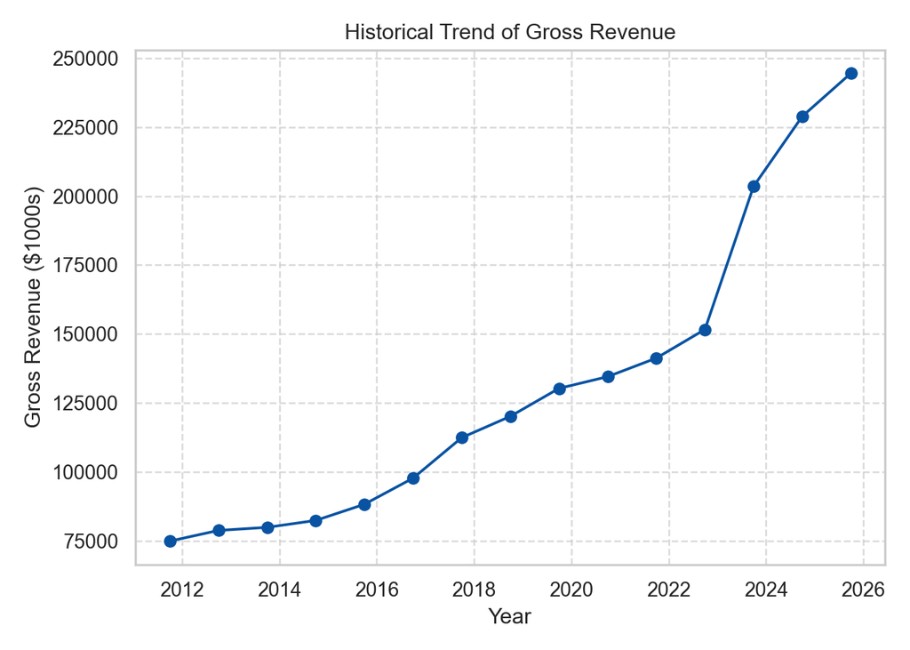

```python
plt.plot(df_revenue['ds'], df_revenue['y'], marker='o', linestyle='-', color='#0953A2')

plt.title('Historical Trend of Gross Revenue')

plt.xlabel('Year')
plt.ylabel('Gross Revenue ($1000s)')
plt.grid(True, linestyle='--', alpha=0.7)
plt.tight_layout()
plt.show()
```

```python
plt.close()
```

#### Build Model

```python
#| include: false

best_params_revenue, tuning_results_revenue = tune_prophet_model(param_grid_prophet, df_revenue)
```

[output not shown]

```python
tuning_results_revenue = tuning_results_revenue.sort_values(by='rmse').reset_index(drop=True)
```

Below is a list of the top 10 hyperparameter combinations and the resulting RMSE score.

```python
create_html_table(tuning_results_revenue.head(10))
```

| changepoint_prior_scale | n_changepoints | growth | rmse |
| --- | --- | --- | --- |
| 0.1 | 8 | linear | 2408.76 |
| 0.1 | 7 | linear | 2408.76 |
| 0.1 | 5 | linear | 2408.76 |
| 0.1 | 6 | linear | 2408.76 |
| 0.2 | 6 | linear | 2674.35 |
| 0.2 | 8 | linear | 2674.35 |
| 0.2 | 5 | linear | 2674.35 |
| 0.2 | 7 | linear | 2674.35 |
| 0.35 | 5 | linear | 2785.32 |
| 0.35 | 7 | linear | 2785.32 |

```python
#| include: false

revenue_model_prophet = initialize_prophet_model(best_params_revenue, df_revenue)
```

Below is the forecast based on the model parameters above.

- `yhat` represents the median predicted value
- `yhat_lower` represents the bottom of the 95% confidence interval
- `yhat_upper` represents the top of the 95% confidence interval

#### Forecast

```python
#| error: false

# Make predictions
revenue_prophet_forecast = generate_prophet_forecast(revenue_model_prophet, periods=6, freq='YE')

create_html_table(revenue_prophet_forecast)
```

| ds | trend | yhat_lower | yhat_upper | trend_lower | trend_upper | acquisition_effect | acquisition_effect_lower | acquisition_effect_upper | additive_terms | additive_terms_lower | additive_terms_upper | extra_regressors_additive | extra_regressors_additive_lower | extra_regressors_additive_upper | multiplicative_terms | multiplicative_terms_lower | multiplicative_terms_upper | yhat |
| --- | --- | --- | --- | --- | --- | --- | --- | --- | --- | --- | --- | --- | --- | --- | --- | --- | --- | --- |
| 2011-09-30 00:00:00 | 75058.5 | 72395.6 | 77729.8 | 75058.5 | 75058.5 | 0 | 0 | 0 | 0 | 0 | 0 | 0 | 0 | 0 | 0 | 0 | 0 | 75058.5 |
| 2012-09-30 00:00:00 | 77409.4 | 74782.5 | 79910.2 | 77409.4 | 77409.4 | 0 | 0 | 0 | 0 | 0 | 0 | 0 | 0 | 0 | 0 | 0 | 0 | 77409.4 |
| 2013-09-30 00:00:00 | 79753.8 | 77299.7 | 82124.9 | 79753.8 | 79753.8 | 0 | 0 | 0 | 0 | 0 | 0 | 0 | 0 | 0 | 0 | 0 | 0 | 79753.8 |
| 2014-09-30 00:00:00 | 82098.3 | 79584.5 | 84582.6 | 82098.3 | 82098.3 | 0 | 0 | 0 | 0 | 0 | 0 | 0 | 0 | 0 | 0 | 0 | 0 | 82098.3 |
| 2015-09-30 00:00:00 | 91211.1 | 88434.1 | 93940.8 | 91211.1 | 91211.1 | 0 | 0 | 0 | 0 | 0 | 0 | 0 | 0 | 0 | 0 | 0 | 0 | 91211.1 |
| 2016-09-30 00:00:00 | 100349 | 97772.3 | 102871 | 100349 | 100349 | 0 | 0 | 0 | 0 | 0 | 0 | 0 | 0 | 0 | 0 | 0 | 0 | 100349 |
| 2017-09-30 00:00:00 | 109475 | 106814 | 112136 | 109475 | 109475 | 0 | 0 | 0 | 0 | 0 | 0 | 0 | 0 | 0 | 0 | 0 | 0 | 109475 |
| 2018-09-30 00:00:00 | 118600 | 116043 | 121058 | 118600 | 118600 | 0 | 0 | 0 | 0 | 0 | 0 | 0 | 0 | 0 | 0 | 0 | 0 | 118600 |
| 2019-09-30 00:00:00 | 127725 | 125149 | 130411 | 127725 | 127725 | 0 | 0 | 0 | 0 | 0 | 0 | 0 | 0 | 0 | 0 | 0 | 0 | 127725 |
| 2020-09-30 00:00:00 | 135607 | 133057 | 138230 | 135607 | 135607 | 0 | 0 | 0 | 0 | 0 | 0 | 0 | 0 | 0 | 0 | 0 | 0 | 135607 |
| 2021-09-30 00:00:00 | 143468 | 141011 | 146063 | 143468 | 143468 | 0 | 0 | 0 | 0 | 0 | 0 | 0 | 0 | 0 | 0 | 0 | 0 | 143468 |
| 2022-09-30 00:00:00 | 151329 | 148583 | 154035 | 151329 | 151329 | 0 | 0 | 0 | 0 | 0 | 0 | 0 | 0 | 0 | 0 | 0 | 0 | 151329 |
| 2023-09-30 00:00:00 | 170687 | 203621 | 208727 | 170687 | 170687 | 35606.1 | 35606.1 | 35606.1 | 35606.1 | 35606.1 | 35606.1 | 35606.1 | 35606.1 | 35606.1 | 0 | 0 | 0 | 206293 |
| 2024-09-30 00:00:00 | 190099 | 223136 | 228284 | 190099 | 190099 | 35606.1 | 35606.1 | 35606.1 | 35606.1 | 35606.1 | 35606.1 | 35606.1 | 35606.1 | 35606.1 | 0 | 0 | 0 | 225705 |
| 2025-09-30 00:00:00 | 209458 | 242294 | 247613 | 209458 | 209458 | 35606.1 | 35606.1 | 35606.1 | 35606.1 | 35606.1 | 35606.1 | 35606.1 | 35606.1 | 35606.1 | 0 | 0 | 0 | 245064 |
| 2025-12-31 00:00:00 | 214338 | 246912 | 252966 | 213094 | 215653 | 35606.1 | 35606.1 | 35606.1 | 35606.1 | 35606.1 | 35606.1 | 35606.1 | 35606.1 | 35606.1 | 0 | 0 | 0 | 249944 |
| 2026-12-31 00:00:00 | 233696 | 264045 | 274406 | 229443 | 237971 | 35606.1 | 35606.1 | 35606.1 | 35606.1 | 35606.1 | 35606.1 | 35606.1 | 35606.1 | 35606.1 | 0 | 0 | 0 | 269302 |
| 2027-12-31 00:00:00 | 253055 | 279374 | 298385 | 244300 | 262618 | 35606.1 | 35606.1 | 35606.1 | 35606.1 | 35606.1 | 35606.1 | 35606.1 | 35606.1 | 35606.1 | 0 | 0 | 0 | 288661 |
| 2028-12-31 00:00:00 | 272467 | 292863 | 323345 | 257978 | 287658 | 35606.1 | 35606.1 | 35606.1 | 35606.1 | 35606.1 | 35606.1 | 35606.1 | 35606.1 | 35606.1 | 0 | 0 | 0 | 308073 |
| 2029-12-31 00:00:00 | 291826 | 305529 | 349109 | 270104 | 313088 | 35606.1 | 35606.1 | 35606.1 | 35606.1 | 35606.1 | 35606.1 | 35606.1 | 35606.1 | 35606.1 | 0 | 0 | 0 | 327432 |
| 2030-12-31 00:00:00 | 311185 | 317168 | 375003 | 282348 | 338854 | 35606.1 | 35606.1 | 35606.1 | 35606.1 | 35606.1 | 35606.1 | 35606.1 | 35606.1 | 35606.1 | 0 | 0 | 0 | 346791 |

#### Evaluation

```python
#| label: Display Revenue Model Performance

create_html_table(revenue_prophet_error)
```

| horizon | mse | rmse | mae | mape | mdape | smape | coverage |
| --- | --- | --- | --- | --- | --- | --- | --- |
| 363 days 00:00:00 | 5.80213e+06 | 2408.76 | 2299.39 | 0.0186281 | 0.0186281 | 0.0184358 | 0.5 |
| 364 days 00:00:00 | 1.28198e+07 | 3580.48 | 3426.24 | 0.0250455 | 0.0250455 | 0.0247038 | 0 |
| 728 days 00:00:00 | 1.75753e+07 | 4192.29 | 4075.89 | 0.0306605 | 0.026586 | 0.0301665 | 0.5 |
| 729 days 00:00:00 | 3.80118e+07 | 6165.37 | 5125.08 | 0.0371966 | 0.0480848 | 0.0362156 | 0.666667 |
| 1094 days 00:00:00 | 5.80767e+08 | 24099.1 | 18690.3 | 0.108604 | 0.0897421 | 0.113252 | 0.25 |
| 1459 days 00:00:00 | 6.23274e+08 | 24965.5 | 22584.6 | 0.130795 | 0.123609 | 0.133438 | 0 |
| 1460 days 00:00:00 | 2.25354e+09 | 47471.5 | 42452.4 | 0.201496 | 0.227973 | 0.224259 | 0 |
| 1824 days 00:00:00 | 5.73774e+08 | 23953.6 | 23508 | 0.131393 | 0.131393 | 0.132855 | 0.5 |
| 1825 days 00:00:00 | 3.91447e+09 | 62565.7 | 62016.7 | 0.261066 | 0.261066 | 0.300787 | 0 |

#### Visualize Forecast

The visualization below shows the forecast for revenue. The model captured historical trends well and provided a tight confidence interval for future values. The purple cone represents a 95% confidence interval.

```python
# Plot historical actual data points
plt.plot(
    df_revenue['ds'],
    df_revenue['y'],
    marker='o',
    linestyle='-',
    color='#00AA65',
    label='Historical Data',
)

# Plot the model's future forecast line
plt.plot(
    revenue_prophet_forecast['ds'],
    revenue_prophet_forecast['yhat'],
    linestyle='--',
    color='#413A8E',
    label='Forecast',
)

# Plot the confidence interval
plt.fill_between(
    revenue_prophet_forecast['ds'],
    revenue_prophet_forecast['yhat_lower'],
    revenue_prophet_forecast['yhat_upper'],
    color='#413A8E',
    alpha=0.2,
    label='Confidence Interval',
)

handles, labels = plt.gca().get_legend_handles_labels()
by_label = dict(zip(labels, handles))
plt.legend(by_label.values(), by_label.keys(), loc='upper left')

# Styling and layout
plt.xlim(df_revenue['ds'].min(), revenue_prophet_forecast['ds'].max())
```

```
(np.float64(15247.0), np.float64(22279.0))
```

```python
plt.title('Historical Trend & Revenue Forecast')
plt.xlabel('Year')
plt.ylabel('Gross Revenue')
plt.grid(True, linestyle='--', alpha=0.7)
plt.xticks(rotation=45)
```

```
(array([14610., 15340., 16071., 16801., 17532., 18262., 18993., 19723.,
       20454., 21184., 21915.]), [Text(14610.0, 0, '2010'), Text(15340.0, 0, '2012'), Text(16071.0, 0, '2014'), Text(16801.0, 0, '2016'), Text(17532.0, 0, '2018'), Text(18262.0, 0, '2020'), Text(18993.0, 0, '2022'), Text(19723.0, 0, '2024'), Text(20454.0, 0, '2026'), Text(21184.0, 0, '2028'), Text(2…
```

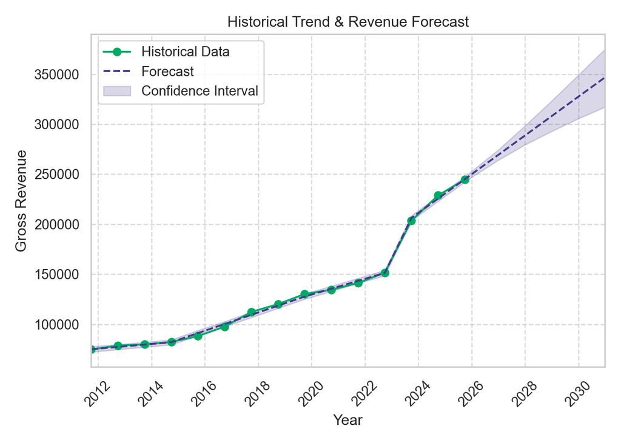

```python
plt.tight_layout()

plt.show()
```

```python
plt.close()
```

## Water Production

Below is a table showing Toho’s water production in Mgal over time.

```python
#| warning: false
#| error: false

df_water = pd.DataFrame({
    "ds": df_toho["ds"],
    "y": df_toho["Water - Raw (Mgal)"],
    "acquisition_effect" : df_toho["acquisition_effect"]

})

df_water = df_water.dropna(subset=['y'])
df_water = df_water[df_water['y'] != 0]


create_html_table(df_water)
```

| ds | y | acquisition_effect |
| --- | --- | --- |
| 2025-09-30 00:00:00 | 1244780 | 1 |
| 2024-09-30 00:00:00 | 1177609 | 1 |
| 2023-09-30 00:00:00 | 1183099 | 1 |
| 2022-09-30 00:00:00 | 957013 | 0 |
| 2021-09-30 00:00:00 | 903186 | 0 |
| 2020-09-30 00:00:00 | 860543 | 0 |
| 2019-09-30 00:00:00 | 852322 | 0 |
| 2018-09-30 00:00:00 | 816800 | 0 |
| 2017-09-30 00:00:00 | 791105 | 0 |
| 2016-09-30 00:00:00 | 782534 | 0 |
| 2015-09-30 00:00:00 | 751223 | 0 |
| 2014-09-30 00:00:00 | 730980 | 0 |
| 2013-09-30 00:00:00 | 716132 | 0 |
| 2012-09-30 00:00:00 | 723001 | 0 |

#### Visualization

The visual below shows a general linear trend followed by the sharp increase when Saint Cloud’s infrastructure was acquired by Toho. It’s difficult to see a clear trend in the data following the event.

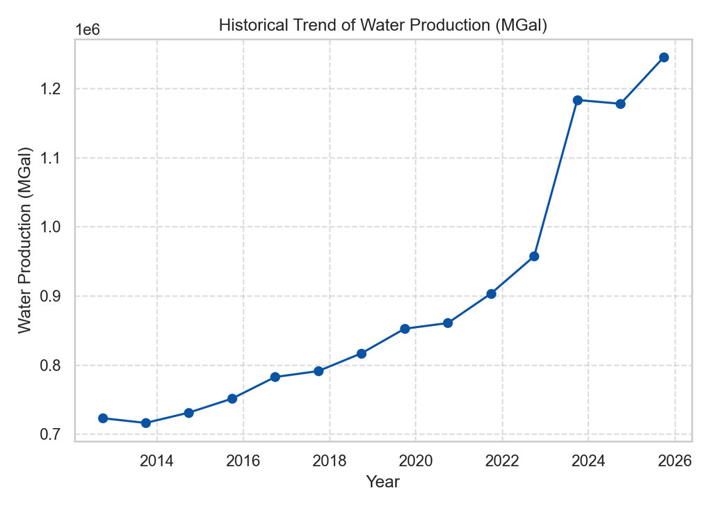

```python
plt.plot(df_water['ds'], df_water['y'], marker='o', linestyle='-', color='#0953A2')

plt.title('Historical Trend of Water Production (MGal)')

plt.xlabel('Year')
plt.ylabel('Water Production (MGal)')
plt.grid(True, linestyle='--', alpha=0.7)
plt.tight_layout()
plt.show()
```

```python
plt.close()
```

#### Build Model

```python
#| include: false

best_params_water, tuning_results_water = tune_prophet_model(param_grid_prophet, df_water)

tuning_results_water = tuning_results_water.sort_values(by='rmse').reset_index(drop=True)
```

Below is a list of the top 10 hyperparameter combinations and the resulting RMSE score.

```python
create_html_table(tuning_results_water.head(10))
```

| changepoint_prior_scale | n_changepoints | growth | rmse |
| --- | --- | --- | --- |
| 0.05 | 8 | linear | 17831.9 |
| 0.05 | 7 | linear | 17831.9 |
| 0.05 | 6 | linear | 17831.9 |
| 0.05 | 5 | linear | 17831.9 |
| 0.1 | 8 | linear | 19960.2 |
| 0.1 | 7 | linear | 19960.2 |
| 0.1 | 6 | linear | 19960.2 |
| 0.1 | 5 | linear | 19960.2 |
| 0.2 | 8 | linear | 20635.4 |
| 0.2 | 7 | linear | 20635.4 |

```python
#| include: false

water_model_prophet = initialize_prophet_model(best_params_water, df_water)
```

#### Forecast

```python
#| error: false

# Make predictions
water_prophet_forecast = generate_prophet_forecast(water_model_prophet, periods=6, freq='YE')

create_html_table(water_prophet_forecast)
```

| ds | trend | yhat_lower | yhat_upper | trend_lower | trend_upper | acquisition_effect | acquisition_effect_lower | acquisition_effect_upper | additive_terms | additive_terms_lower | additive_terms_upper | extra_regressors_additive | extra_regressors_additive_lower | extra_regressors_additive_upper | multiplicative_terms | multiplicative_terms_lower | multiplicative_terms_upper | yhat |
| --- | --- | --- | --- | --- | --- | --- | --- | --- | --- | --- | --- | --- | --- | --- | --- | --- | --- | --- |
| 2012-09-30 00:00:00 | 704096 | 688871 | 719634 | 704096 | 704096 | 0 | 0 | 0 | 0 | 0 | 0 | 0 | 0 | 0 | 0 | 0 | 0 | 704096 |
| 2013-09-30 00:00:00 | 722111 | 706340 | 738750 | 722111 | 722111 | 0 | 0 | 0 | 0 | 0 | 0 | 0 | 0 | 0 | 0 | 0 | 0 | 722111 |
| 2014-09-30 00:00:00 | 740125 | 724435 | 756344 | 740125 | 740125 | 0 | 0 | 0 | 0 | 0 | 0 | 0 | 0 | 0 | 0 | 0 | 0 | 740125 |
| 2015-09-30 00:00:00 | 758295 | 742790 | 773244 | 758295 | 758295 | 0 | 0 | 0 | 0 | 0 | 0 | 0 | 0 | 0 | 0 | 0 | 0 | 758295 |
| 2016-09-30 00:00:00 | 776515 | 760254 | 793056 | 776515 | 776515 | 0 | 0 | 0 | 0 | 0 | 0 | 0 | 0 | 0 | 0 | 0 | 0 | 776515 |
| 2017-09-30 00:00:00 | 796490 | 780197 | 811278 | 796490 | 796490 | 0 | 0 | 0 | 0 | 0 | 0 | 0 | 0 | 0 | 0 | 0 | 0 | 796490 |
| 2018-09-30 00:00:00 | 816465 | 800553 | 831838 | 816465 | 816465 | 0 | 0 | 0 | 0 | 0 | 0 | 0 | 0 | 0 | 0 | 0 | 0 | 816465 |
| 2019-09-30 00:00:00 | 846911 | 831214 | 863691 | 846911 | 846911 | 0 | 0 | 0 | 0 | 0 | 0 | 0 | 0 | 0 | 0 | 0 | 0 | 846911 |
| 2020-09-30 00:00:00 | 877441 | 861881 | 892992 | 877441 | 877441 | 0 | 0 | 0 | 0 | 0 | 0 | 0 | 0 | 0 | 0 | 0 | 0 | 877441 |
| 2021-09-30 00:00:00 | 907937 | 892240 | 923236 | 907937 | 907937 | 0 | 0 | 0 | 0 | 0 | 0 | 0 | 0 | 0 | 0 | 0 | 0 | 907937 |
| 2022-09-30 00:00:00 | 938434 | 923268 | 954234 | 938434 | 938434 | 0 | 0 | 0 | 0 | 0 | 0 | 0 | 0 | 0 | 0 | 0 | 0 | 938434 |
| 2023-09-30 00:00:00 | 968931 | 1.15611e+06 | 1.18714e+06 | 968931 | 968931 | 202352 | 202352 | 202352 | 202352 | 202352 | 202352 | 202352 | 202352 | 202352 | 0 | 0 | 0 | 1.17128e+06 |
| 2024-09-30 00:00:00 | 999511 | 1.18579e+06 | 1.21744e+06 | 999511 | 999511 | 202352 | 202352 | 202352 | 202352 | 202352 | 202352 | 202352 | 202352 | 202352 | 0 | 0 | 0 | 1.20186e+06 |
| 2025-09-30 00:00:00 | 1.03001e+06 | 1.2168e+06 | 1.24792e+06 | 1.03001e+06 | 1.03001e+06 | 202352 | 202352 | 202352 | 202352 | 202352 | 202352 | 202352 | 202352 | 202352 | 0 | 0 | 0 | 1.23236e+06 |
| 2025-12-31 00:00:00 | 1.03769e+06 | 1.22431e+06 | 1.25573e+06 | 1.03688e+06 | 1.0384e+06 | 202352 | 202352 | 202352 | 202352 | 202352 | 202352 | 202352 | 202352 | 202352 | 0 | 0 | 0 | 1.24005e+06 |
| 2026-12-31 00:00:00 | 1.06819e+06 | 1.25535e+06 | 1.28658e+06 | 1.06511e+06 | 1.07075e+06 | 202352 | 202352 | 202352 | 202352 | 202352 | 202352 | 202352 | 202352 | 202352 | 0 | 0 | 0 | 1.27054e+06 |
| 2027-12-31 00:00:00 | 1.09869e+06 | 1.28241e+06 | 1.31787e+06 | 1.0922e+06 | 1.1046e+06 | 202352 | 202352 | 202352 | 202352 | 202352 | 202352 | 202352 | 202352 | 202352 | 0 | 0 | 0 | 1.30104e+06 |
| 2028-12-31 00:00:00 | 1.12927e+06 | 1.31e+06 | 1.35181e+06 | 1.11814e+06 | 1.13925e+06 | 202352 | 202352 | 202352 | 202352 | 202352 | 202352 | 202352 | 202352 | 202352 | 0 | 0 | 0 | 1.33162e+06 |
| 2029-12-31 00:00:00 | 1.15977e+06 | 1.33924e+06 | 1.38582e+06 | 1.14338e+06 | 1.17537e+06 | 202352 | 202352 | 202352 | 202352 | 202352 | 202352 | 202352 | 202352 | 202352 | 0 | 0 | 0 | 1.36212e+06 |
| 2030-12-31 00:00:00 | 1.19026e+06 | 1.3646e+06 | 1.41958e+06 | 1.16888e+06 | 1.21118e+06 | 202352 | 202352 | 202352 | 202352 | 202352 | 202352 | 202352 | 202352 | 202352 | 0 | 0 | 0 | 1.39261e+06 |

#### Evaluation

```python
# Run cross-validation with custom parameters tailored for annual data
water_prophet_evaluation = cross_validation(
    water_model_prophet,
    initial='2190 days',  # ~6 years of initial training data
    period='365 days',  # Step forward by 1 year for each test fold
    horizon='1825 days',
)
```

```
 33%|###3      | 1/3 [00:00<00:00,  2.92it/s]
 67%|######6   | 2/3 [00:00<00:00,  3.33it/s]
```

```python
# Calculate error metrics (MAE, RMSE, MAPE)
water_prophet_error = performance_metrics(water_prophet_evaluation)
```

```python
create_html_table(water_prophet_error.head(10))
```

| horizon | mse | rmse | mae | mape | mdape | smape | coverage |
| --- | --- | --- | --- | --- | --- | --- | --- |
| 363 days 00:00:00 | 3.17976e+08 | 17831.9 | 17831.9 | 0.0209215 | 0.0209215 | 0.0211427 | 0 |
| 364 days 00:00:00 | 2.45888e+08 | 15680.8 | 15638 | 0.0177115 | 0.0177115 | 0.0177286 | 0 |
| 729 days 00:00:00 | 7.99901e+08 | 28282.5 | 18910.3 | 0.0200529 | 0.00777379 | 0.0205027 | 0.666667 |
| 1094 days 00:00:00 | 2.18229e+10 | 147726 | 103744 | 0.0922231 | 0.0332405 | 0.101059 | 0.333333 |
| 1459 days 00:00:00 | 2.81206e+10 | 167692 | 146370 | 0.130161 | 0.130161 | 0.141632 | 0 |
| 1460 days 00:00:00 | 5.05354e+10 | 224801 | 224801 | 0.190896 | 0.190896 | 0.211039 | 0 |
| 1824 days 00:00:00 | 7.36117e+10 | 271315 | 271315 | 0.229325 | 0.229325 | 0.259026 | 0 |
| 1825 days 00:00:00 | 5.5621e+10 | 235841 | 232933 | 0.191619 | 0.191619 | 0.212352 | 0 |

#### Visualize Forecast

The visualization below shows the forecast for water production in Mgal. The model captured historical trends well and provided a tight confidence interval for future values. The purple cone represents a 95% confidence interval.

```python
#| label: Visualize Water Forecast

# 1. Plot historical actual data points
plt.plot(
    df_water['ds'],
    df_water['y'],
    marker='o',
    linestyle='-',
    color='#00AA65',
    label='Historical Data',
)

# 2. Plot the model's future forecast line
plt.plot(
    water_prophet_forecast['ds'],
    water_prophet_forecast['yhat'],
    linestyle='--',
    color='#413A8E',
    label='Forecast',
)

# 3. Plot the confidence interval
plt.fill_between(
    water_prophet_forecast['ds'],
    water_prophet_forecast['yhat_lower'],
    water_prophet_forecast['yhat_upper'],
    color='#413A8E',
    alpha=0.2,
    label='Confidence Interval',
)

handles, labels = plt.gca().get_legend_handles_labels()
by_label = dict(zip(labels, handles))
plt.legend(by_label.values(), by_label.keys(), loc='upper left')

# Styling and layout
plt.xlim(df_water['ds'].min(), water_prophet_forecast['ds'].max())
```

```
(np.float64(15613.0), np.float64(22279.0))
```

```python
plt.title('Historical Trend & Water Production (MGal) Forecast')
plt.xlabel('Year')
plt.ylabel('Water Production (MGal)')
plt.grid(True, linestyle='--', alpha=0.7)
plt.xticks(rotation=45)
```

```
(array([15340., 16071., 16801., 17532., 18262., 18993., 19723., 20454.,
       21184., 21915.]), [Text(15340.0, 0, '2012'), Text(16071.0, 0, '2014'), Text(16801.0, 0, '2016'), Text(17532.0, 0, '2018'), Text(18262.0, 0, '2020'), Text(18993.0, 0, '2022'), Text(19723.0, 0, '2024'), Text(20454.0, 0, '2026'), Text(21184.0, 0, '2028'), Text(21915.0, 0, '2030')])
```

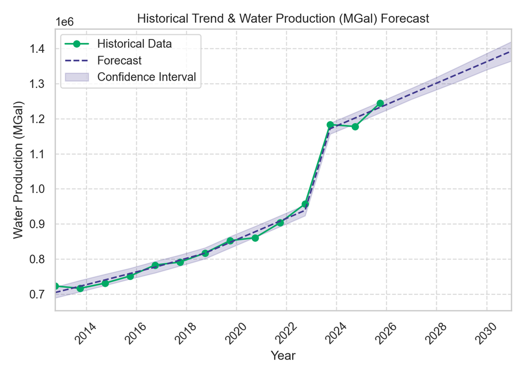

```python
plt.tight_layout()

plt.show()
```

```python
plt.close()
```

## Wastewater

Below is a table showing Toho’s wastewater in Mgal over time.

```python
#| warning: false
#| error: false

df_wastewater = pd.DataFrame({
    "ds": df_toho["ds"],
    "y": df_toho["Wastewater (Mgal)"],
    "acquisition_effect" : df_toho["acquisition_effect"]

})

df_wastewater = df_wastewater.dropna(subset=['y'])
df_wastewater = df_wastewater[df_wastewater['y'] != 0]


create_html_table(df_wastewater)
```

| ds | y | acquisition_effect |
| --- | --- | --- |
| 2025-09-30 00:00:00 | 1135613 | 1 |
| 2024-09-30 00:00:00 | 1072579 | 1 |
| 2023-09-30 00:00:00 | 1072750 | 1 |
| 2022-09-30 00:00:00 | 874497 | 0 |
| 2021-09-30 00:00:00 | 830870 | 0 |
| 2020-09-30 00:00:00 | 776941 | 0 |
| 2019-09-30 00:00:00 | 782217 | 0 |
| 2018-09-30 00:00:00 | 752210 | 0 |
| 2017-09-30 00:00:00 | 709179 | 0 |
| 2016-09-30 00:00:00 | 716930 | 0 |
| 2015-09-30 00:00:00 | 677193 | 0 |
| 2014-09-30 00:00:00 | 666284 | 0 |
| 2013-09-30 00:00:00 | 650768 | 0 |
| 2012-09-30 00:00:00 | 642722 | 0 |

#### Visualization

The visual below shows a general linear trend followed by the sharp increase when Saint Cloud’s infrastructure was acquired by Toho. It’s difficult to see a clear trend in the data following the event.

[figure not shown]

```python
#| label: Visualize Wastewater Data

plt.plot(df_wastewater['ds'], df_water['y'], marker='o', linestyle='-', color='#00AA65')

plt.title('Historical Trend of Wastewater Treatment (MGal)')

plt.xlabel('Year')
plt.ylabel('Wastewater Treatment (MGal)')
plt.grid(True, linestyle='--', alpha=0.7)
plt.tight_layout()
plt.show()
```

```python
plt.close()
```

#### Build Model

```python
#| include: false

best_params_wastewater, tuning_results_wastewater = tune_prophet_model(param_grid_prophet, df_wastewater)

tuning_results_wastewater = tuning_results_wastewater.sort_values(by='rmse').reset_index(drop=True)
```

Below is a list of the top 10 hyperparameter combinations and the resulting RMSE score.

```python
#| label: Display Wastewater Model Parameter Performance

create_html_table(tuning_results_wastewater.head(10))
```

| changepoint_prior_scale | n_changepoints | growth | rmse |
| --- | --- | --- | --- |
| 0.2 | 8 | linear | 15455.3 |
| 0.2 | 7 | linear | 15455.3 |
| 0.2 | 6 | linear | 15455.3 |
| 0.2 | 5 | linear | 15455.3 |
| 0.1 | 5 | linear | 16979.8 |
| 0.1 | 6 | linear | 16979.8 |
| 0.1 | 7 | linear | 16979.8 |
| 0.1 | 8 | linear | 16979.8 |
| 0.35 | 8 | linear | 17374.6 |
| 0.35 | 7 | linear | 17374.6 |

```python
#| include: false
wastewater_model_prophet = initialize_prophet_model(best_params_wastewater, df_wastewater)
```

#### Forecast

```python
#| error: false

# Make predictions
wastewater_prophet_forecast = generate_prophet_forecast(wastewater_model_prophet, periods=6, freq='YE')

create_html_table(wastewater_prophet_forecast)
```

| ds | trend | yhat_lower | yhat_upper | trend_lower | trend_upper | acquisition_effect | acquisition_effect_lower | acquisition_effect_upper | additive_terms | additive_terms_lower | additive_terms_upper | extra_regressors_additive | extra_regressors_additive_lower | extra_regressors_additive_upper | multiplicative_terms | multiplicative_terms_lower | multiplicative_terms_upper | yhat |
| --- | --- | --- | --- | --- | --- | --- | --- | --- | --- | --- | --- | --- | --- | --- | --- | --- | --- | --- |
| 2012-09-30 00:00:00 | 638800 | 625407 | 652352 | 638800 | 638800 | 0 | 0 | 0 | 0 | 0 | 0 | 0 | 0 | 0 | 0 | 0 | 0 | 638800 |
| 2013-09-30 00:00:00 | 651943 | 638795 | 665644 | 651943 | 651943 | 0 | 0 | 0 | 0 | 0 | 0 | 0 | 0 | 0 | 0 | 0 | 0 | 651943 |
| 2014-09-30 00:00:00 | 665087 | 651187 | 678635 | 665087 | 665087 | 0 | 0 | 0 | 0 | 0 | 0 | 0 | 0 | 0 | 0 | 0 | 0 | 665087 |
| 2015-09-30 00:00:00 | 685065 | 670203 | 698815 | 685065 | 685065 | 0 | 0 | 0 | 0 | 0 | 0 | 0 | 0 | 0 | 0 | 0 | 0 | 685065 |
| 2016-09-30 00:00:00 | 705097 | 691946 | 719041 | 705097 | 705097 | 0 | 0 | 0 | 0 | 0 | 0 | 0 | 0 | 0 | 0 | 0 | 0 | 705097 |
| 2017-09-30 00:00:00 | 726619 | 713425 | 740140 | 726619 | 726619 | 0 | 0 | 0 | 0 | 0 | 0 | 0 | 0 | 0 | 0 | 0 | 0 | 726619 |
| 2018-09-30 00:00:00 | 748140 | 733738 | 762875 | 748140 | 748140 | 0 | 0 | 0 | 0 | 0 | 0 | 0 | 0 | 0 | 0 | 0 | 0 | 748140 |
| 2019-09-30 00:00:00 | 769661 | 755830 | 783590 | 769661 | 769661 | 0 | 0 | 0 | 0 | 0 | 0 | 0 | 0 | 0 | 0 | 0 | 0 | 769661 |
| 2020-09-30 00:00:00 | 791242 | 776899 | 804374 | 791242 | 791242 | 0 | 0 | 0 | 0 | 0 | 0 | 0 | 0 | 0 | 0 | 0 | 0 | 791242 |
| 2021-09-30 00:00:00 | 829799 | 815505 | 843864 | 829799 | 829799 | 0 | 0 | 0 | 0 | 0 | 0 | 0 | 0 | 0 | 0 | 0 | 0 | 829799 |
| 2022-09-30 00:00:00 | 868356 | 855145 | 881895 | 868356 | 868356 | 0 | 0 | 0 | 0 | 0 | 0 | 0 | 0 | 0 | 0 | 0 | 0 | 868356 |
| 2023-09-30 00:00:00 | 903061 | 1.0453e+06 | 1.07327e+06 | 903061 | 903061 | 155818 | 155818 | 155818 | 155818 | 155818 | 155818 | 155818 | 155818 | 155818 | 0 | 0 | 0 | 1.05888e+06 |
| 2024-09-30 00:00:00 | 937861 | 1.08012e+06 | 1.10758e+06 | 937861 | 937861 | 155818 | 155818 | 155818 | 155818 | 155818 | 155818 | 155818 | 155818 | 155818 | 0 | 0 | 0 | 1.09368e+06 |
| 2025-09-30 00:00:00 | 972567 | 1.11497e+06 | 1.14223e+06 | 972567 | 972567 | 155818 | 155818 | 155818 | 155818 | 155818 | 155818 | 155818 | 155818 | 155818 | 0 | 0 | 0 | 1.12838e+06 |
| 2025-12-31 00:00:00 | 981314 | 1.12322e+06 | 1.15131e+06 | 979507 | 982856 | 155818 | 155818 | 155818 | 155818 | 155818 | 155818 | 155818 | 155818 | 155818 | 0 | 0 | 0 | 1.13713e+06 |
| 2026-12-31 00:00:00 | 1.01602e+06 | 1.15504e+06 | 1.18774e+06 | 1.01005e+06 | 1.02253e+06 | 155818 | 155818 | 155818 | 155818 | 155818 | 155818 | 155818 | 155818 | 155818 | 0 | 0 | 0 | 1.17184e+06 |
| 2027-12-31 00:00:00 | 1.05072e+06 | 1.1866e+06 | 1.22679e+06 | 1.03756e+06 | 1.06499e+06 | 155818 | 155818 | 155818 | 155818 | 155818 | 155818 | 155818 | 155818 | 155818 | 0 | 0 | 0 | 1.20654e+06 |
| 2028-12-31 00:00:00 | 1.08553e+06 | 1.215e+06 | 1.26734e+06 | 1.06341e+06 | 1.10849e+06 | 155818 | 155818 | 155818 | 155818 | 155818 | 155818 | 155818 | 155818 | 155818 | 0 | 0 | 0 | 1.24134e+06 |
| 2029-12-31 00:00:00 | 1.12023e+06 | 1.24025e+06 | 1.31293e+06 | 1.08617e+06 | 1.15486e+06 | 155818 | 155818 | 155818 | 155818 | 155818 | 155818 | 155818 | 155818 | 155818 | 0 | 0 | 0 | 1.27605e+06 |
| 2030-12-31 00:00:00 | 1.15494e+06 | 1.26352e+06 | 1.36005e+06 | 1.10898e+06 | 1.20356e+06 | 155818 | 155818 | 155818 | 155818 | 155818 | 155818 | 155818 | 155818 | 155818 | 0 | 0 | 0 | 1.31075e+06 |

#### Evaluation

```python
#| include: false

# Run cross-validation with custom parameters tailored for annual data
wastewater_prophet_evaluation = cross_validation(wastewater_model_prophet,
  initial='2190 days',  # ~6 years of initial training data
  period='365 days',  # Step forward by 1 year for each test fold
  horizon='1825 days', )  # Calculate error metrics (MAE, RMSE, MAPE)
```

```
 33%|###3      | 1/3 [00:00<00:00,  4.39it/s]
 67%|######6   | 2/3 [00:00<00:00,  4.35it/s]
```

```python
wastewater_prophet_error = performance_metrics(wastewater_prophet_evaluation)
```

```python
create_html_table(wastewater_prophet_error.head(10))
```

| horizon | mse | rmse | mae | mape | mdape | smape | coverage |
| --- | --- | --- | --- | --- | --- | --- | --- |
| 363 days 00:00:00 | 2.38865e+08 | 15455.3 | 15455.3 | 0.0197583 | 0.0197583 | 0.0199554 | 0 |
| 364 days 00:00:00 | 1.28359e+09 | 35827.2 | 34680.5 | 0.0435642 | 0.0435642 | 0.0430386 | 0 |
| 729 days 00:00:00 | 1.11732e+09 | 33426.4 | 29190.8 | 0.0344284 | 0.0313046 | 0.0348074 | 0.666667 |
| 1094 days 00:00:00 | 1.79084e+10 | 133822 | 90137.6 | 0.0873064 | 0.0261826 | 0.0959292 | 0.333333 |
| 1459 days 00:00:00 | 1.1251e+10 | 106071 | 93785 | 0.0920988 | 0.0920988 | 0.0975379 | 0.5 |
| 1460 days 00:00:00 | 4.45238e+10 | 211007 | 211007 | 0.196728 | 0.196728 | 0.21819 | 0 |
| 1824 days 00:00:00 | 4.89907e+10 | 221338 | 221338 | 0.206328 | 0.206328 | 0.230062 | 0 |
| 1825 days 00:00:00 | 3.82821e+10 | 195658 | 181030 | 0.162175 | 0.162175 | 0.179015 | 0.5 |

## Water Connections

Below is a table showing Toho’s water connections over time.

```python
#| warning: false
#| error: false
#| label: Display Connections Data

df_connections = pd.DataFrame({
    "ds": df_toho["ds"],
    "y": df_toho["Total Customers/Connections - Water"],
    "acquisition_effect" : df_toho["acquisition_effect"]

})

df_connections = df_connections.dropna(subset=['y'])
df_connections = df_connections[df_connections['y'] != 0]

create_html_table(df_connections)
```

| ds | y | acquisition_effect |
| --- | --- | --- |
| 2025-09-30 00:00:00 | 167323 | 1 |
| 2024-09-30 00:00:00 | 159829 | 1 |
| 2023-09-30 00:00:00 | 157425 | 1 |
| 2022-09-30 00:00:00 | 121033 | 0 |
| 2021-09-30 00:00:00 | 116719 | 0 |
| 2020-09-30 00:00:00 | 112089 | 0 |
| 2019-09-30 00:00:00 | 107798 | 0 |
| 2018-09-30 00:00:00 | 103165 | 0 |
| 2017-09-30 00:00:00 | 99939 | 0 |
| 2016-09-30 00:00:00 | 96755 | 0 |
| 2015-09-30 00:00:00 | 93210 | 0 |
| 2014-09-30 00:00:00 | 90126 | 0 |
| 2013-09-30 00:00:00 | 87592 | 0 |
| 2012-09-30 00:00:00 | 85776 | 0 |

#### Visualization

The visual below shows a general linear trend followed by the sharp increase when Saint Cloud’s infrastructure was acquired by Toho. It’s difficult to see a clear trend in the data following the event.

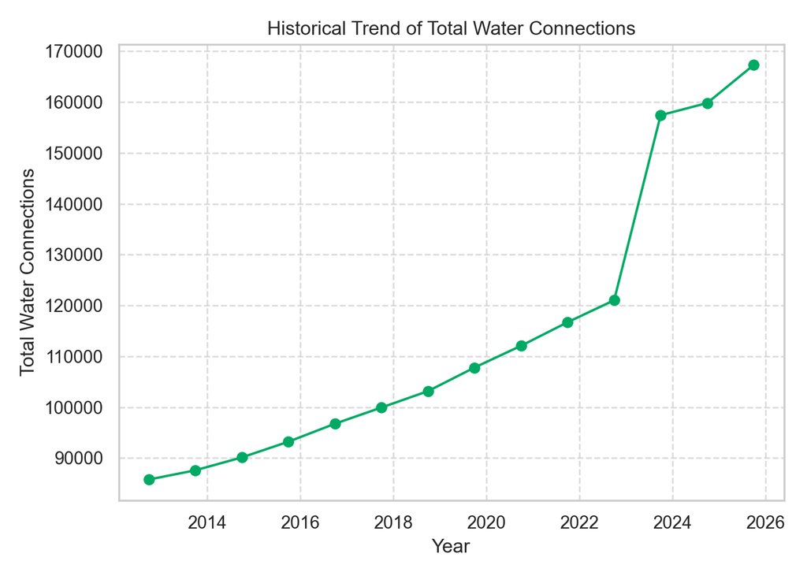

```python
#| paged-print: false

plt.plot(df_connections['ds'],
  df_connections['y'],
  marker='o',
  linestyle='-',
  color='#00AA65')

plt.title('Historical Trend of Total Water Connections')

plt.xlabel('Year')
plt.ylabel('Total Water Connections')
plt.grid(True, linestyle='--', alpha=0.7)
plt.tight_layout()
plt.show()
```

```python
plt.close()
```

#### Build Model

```python
#| include: false

best_params_connections, tuning_results_connections = tune_prophet_model(param_grid_prophet, df_connections)

tuning_results_connections = tuning_results_connections.sort_values(by='rmse').reset_index(drop=True)
```

Below is a list of the top 10 hyperparameter combinations and the resulting RMSE score.

```python
#| label: Display Connections Model Parameter Performance

create_html_table(tuning_results_connections.head(10))
```

| changepoint_prior_scale | n_changepoints | growth | rmse |
| --- | --- | --- | --- |
| 0.01 | 8 | linear | 1434.43 |
| 0.01 | 7 | linear | 1434.43 |
| 0.01 | 6 | linear | 1434.43 |
| 0.01 | 5 | linear | 1434.43 |
| 0.05 | 8 | linear | 1434.89 |
| 0.05 | 7 | linear | 1434.89 |
| 0.05 | 6 | linear | 1434.89 |
| 0.05 | 5 | linear | 1434.89 |
| 0.1 | 5 | linear | 1434.94 |
| 0.1 | 6 | linear | 1434.94 |

```python
#| include: false
connections_model_prophet = initialize_prophet_model(best_params_connections, df_connections)
```

#### Forecast

```python
#| error: false

# Make predictions
connections_prophet_forecast = generate_prophet_forecast(connections_model_prophet, periods=6, freq='YE')

create_html_table(connections_prophet_forecast)
```

| ds | trend | yhat_lower | yhat_upper | trend_lower | trend_upper | acquisition_effect | acquisition_effect_lower | acquisition_effect_upper | additive_terms | additive_terms_lower | additive_terms_upper | extra_regressors_additive | extra_regressors_additive_lower | extra_regressors_additive_upper | multiplicative_terms | multiplicative_terms_lower | multiplicative_terms_upper | yhat |
| --- | --- | --- | --- | --- | --- | --- | --- | --- | --- | --- | --- | --- | --- | --- | --- | --- | --- | --- |
| 2012-09-30 00:00:00 | 83259.4 | 81370.5 | 85037.9 | 83259.4 | 83259.4 | 0 | 0 | 0 | 0 | 0 | 0 | 0 | 0 | 0 | 0 | 0 | 0 | 83259.4 |
| 2013-09-30 00:00:00 | 86862.2 | 85135 | 88666 | 86862.2 | 86862.2 | 0 | 0 | 0 | 0 | 0 | 0 | 0 | 0 | 0 | 0 | 0 | 0 | 86862.2 |
| 2014-09-30 00:00:00 | 90464.9 | 88759.5 | 92247.8 | 90464.9 | 90464.9 | 0 | 0 | 0 | 0 | 0 | 0 | 0 | 0 | 0 | 0 | 0 | 0 | 90464.9 |
| 2015-09-30 00:00:00 | 94067.6 | 92302.7 | 95881.4 | 94067.6 | 94067.6 | 0 | 0 | 0 | 0 | 0 | 0 | 0 | 0 | 0 | 0 | 0 | 0 | 94067.6 |
| 2016-09-30 00:00:00 | 97680.2 | 95976.9 | 99348.3 | 97680.2 | 97680.2 | 0 | 0 | 0 | 0 | 0 | 0 | 0 | 0 | 0 | 0 | 0 | 0 | 97680.2 |
| 2017-09-30 00:00:00 | 101285 | 99553.2 | 102891 | 101285 | 101285 | 0 | 0 | 0 | 0 | 0 | 0 | 0 | 0 | 0 | 0 | 0 | 0 | 101285 |
| 2018-09-30 00:00:00 | 104889 | 103231 | 106619 | 104889 | 104889 | 0 | 0 | 0 | 0 | 0 | 0 | 0 | 0 | 0 | 0 | 0 | 0 | 104889 |
| 2019-09-30 00:00:00 | 108499 | 106739 | 110213 | 108499 | 108499 | 0 | 0 | 0 | 0 | 0 | 0 | 0 | 0 | 0 | 0 | 0 | 0 | 108499 |
| 2020-09-30 00:00:00 | 112120 | 110321 | 113846 | 112120 | 112120 | 0 | 0 | 0 | 0 | 0 | 0 | 0 | 0 | 0 | 0 | 0 | 0 | 112120 |
| 2021-09-30 00:00:00 | 115732 | 113991 | 117493 | 115732 | 115732 | 0 | 0 | 0 | 0 | 0 | 0 | 0 | 0 | 0 | 0 | 0 | 0 | 115732 |
| 2022-09-30 00:00:00 | 119344 | 117662 | 121092 | 119344 | 119344 | 0 | 0 | 0 | 0 | 0 | 0 | 0 | 0 | 0 | 0 | 0 | 0 | 119344 |
| 2023-09-30 00:00:00 | 122956 | 156066 | 159657 | 122956 | 122956 | 34951.4 | 34951.4 | 34951.4 | 34951.4 | 34951.4 | 34951.4 | 34951.4 | 34951.4 | 34951.4 | 0 | 0 | 0 | 157907 |
| 2024-09-30 00:00:00 | 126578 | 159680 | 163149 | 126578 | 126578 | 34951.4 | 34951.4 | 34951.4 | 34951.4 | 34951.4 | 34951.4 | 34951.4 | 34951.4 | 34951.4 | 0 | 0 | 0 | 161529 |
| 2025-09-30 00:00:00 | 130190 | 163507 | 166935 | 130190 | 130190 | 34951.4 | 34951.4 | 34951.4 | 34951.4 | 34951.4 | 34951.4 | 34951.4 | 34951.4 | 34951.4 | 0 | 0 | 0 | 165141 |
| 2025-12-31 00:00:00 | 131100 | 164489 | 167952 | 131100 | 131101 | 34951.4 | 34951.4 | 34951.4 | 34951.4 | 34951.4 | 34951.4 | 34951.4 | 34951.4 | 34951.4 | 0 | 0 | 0 | 166051 |
| 2026-12-31 00:00:00 | 134712 | 167771 | 171342 | 134710 | 134714 | 34951.4 | 34951.4 | 34951.4 | 34951.4 | 34951.4 | 34951.4 | 34951.4 | 34951.4 | 34951.4 | 0 | 0 | 0 | 169663 |
| 2027-12-31 00:00:00 | 138324 | 171579 | 175031 | 138320 | 138329 | 34951.4 | 34951.4 | 34951.4 | 34951.4 | 34951.4 | 34951.4 | 34951.4 | 34951.4 | 34951.4 | 0 | 0 | 0 | 173275 |
| 2028-12-31 00:00:00 | 141946 | 175101 | 178667 | 141939 | 141955 | 34951.4 | 34951.4 | 34951.4 | 34951.4 | 34951.4 | 34951.4 | 34951.4 | 34951.4 | 34951.4 | 0 | 0 | 0 | 176897 |
| 2029-12-31 00:00:00 | 145558 | 178789 | 182270 | 145548 | 145571 | 34951.4 | 34951.4 | 34951.4 | 34951.4 | 34951.4 | 34951.4 | 34951.4 | 34951.4 | 34951.4 | 0 | 0 | 0 | 180509 |
| 2030-12-31 00:00:00 | 149170 | 182383 | 185696 | 149156 | 149187 | 34951.4 | 34951.4 | 34951.4 | 34951.4 | 34951.4 | 34951.4 | 34951.4 | 34951.4 | 34951.4 | 0 | 0 | 0 | 184121 |

#### Evaluation

```python
#| include: false

# Run cross-validation with custom parameters tailored for annual data
connections_prophet_evaluation = cross_validation(connections_model_prophet,
  initial='2190 days',  # ~6 years of initial training data
  period='365 days',  # Step forward by 1 year for each test fold
  horizon='1825 days', )  # Calculate error metrics (MAE, RMSE, MAPE)
```

```
 33%|###3      | 1/3 [00:00<00:00,  3.51it/s]
 67%|######6   | 2/3 [00:00<00:00,  3.70it/s]
```

```python
connections_prophet_error = performance_metrics(connections_prophet_evaluation)
```

```python
create_html_table(connections_prophet_error.head(10))
```

| horizon | mse | rmse | mae | mape | mdape | smape | coverage |
| --- | --- | --- | --- | --- | --- | --- | --- |
| 363 days 00:00:00 | 2.05759e+06 | 1434.43 | 1434.43 | 0.0133066 | 0.0133066 | 0.0133958 | 0 |
| 364 days 00:00:00 | 6.58923e+06 | 2566.95 | 2557.64 | 0.0223267 | 0.0223267 | 0.0225798 | 0 |
| 729 days 00:00:00 | 1.17158e+07 | 3422.83 | 3368.68 | 0.0287729 | 0.0312341 | 0.0292037 | 0 |
| 1094 days 00:00:00 | 4.6636e+08 | 21595.4 | 15257.4 | 0.102991 | 0.0410933 | 0.113822 | 0 |
| 1459 days 00:00:00 | 7.4276e+08 | 27253.6 | 21627.7 | 0.142202 | 0.142202 | 0.159408 | 0 |
| 1460 days 00:00:00 | 1.29224e+09 | 35947.8 | 35947.8 | 0.224914 | 0.224914 | 0.253412 | 0 |
| 1824 days 00:00:00 | 1.46162e+09 | 38231.2 | 38231.2 | 0.242853 | 0.242853 | 0.276418 | 0 |
| 1825 days 00:00:00 | 1.5066e+09 | 38814.9 | 38791.8 | 0.237085 | 0.237085 | 0.268975 | 0 |

#### Visualize Forecast

The visualization below shows the forecast for water connections. The model captured historical trends well and provided a tight confidence interval for future values. The purple cone represents a 95% confidence interval.

```python
#| label: Visualize Connections Forecast

# 1. Plot historical actual data points
plt.plot(
    df_connections['ds'],
    df_connections['y'],
    marker='o',
    linestyle='-',
    color='#00AA65',
    label='Historical Data',
)

# 2. Plot the model's future forecast line
plt.plot(
    connections_prophet_forecast['ds'],
    connections_prophet_forecast['yhat'],
    linestyle='--',
    color='#413A8E',
    label='Forecast',
)

# 3. Plot the confidence interval
plt.fill_between(
    connections_prophet_forecast['ds'],
    connections_prophet_forecast['yhat_lower'],
    connections_prophet_forecast['yhat_upper'],
    color='#413A8E',
    alpha=0.2,
    label='Confidence Interval',
)

handles, labels = plt.gca().get_legend_handles_labels()
by_label = dict(zip(labels, handles))
plt.legend(by_label.values(), by_label.keys(), loc='upper left')

# Styling and layout
plt.xlim(df_connections['ds'].min(), connections_prophet_forecast['ds'].max())
```

```
(np.float64(15613.0), np.float64(22279.0))
```

```python
plt.title('Historical Trend & Water Connections Forecast')
plt.xlabel('Year')
plt.ylabel('Total Water Connections')
plt.grid(True, linestyle='--', alpha=0.7)
plt.xticks(rotation=45)
```

```
(array([15340., 16071., 16801., 17532., 18262., 18993., 19723., 20454.,
       21184., 21915.]), [Text(15340.0, 0, '2012'), Text(16071.0, 0, '2014'), Text(16801.0, 0, '2016'), Text(17532.0, 0, '2018'), Text(18262.0, 0, '2020'), Text(18993.0, 0, '2022'), Text(19723.0, 0, '2024'), Text(20454.0, 0, '2026'), Text(21184.0, 0, '2028'), Text(21915.0, 0, '2030')])
```

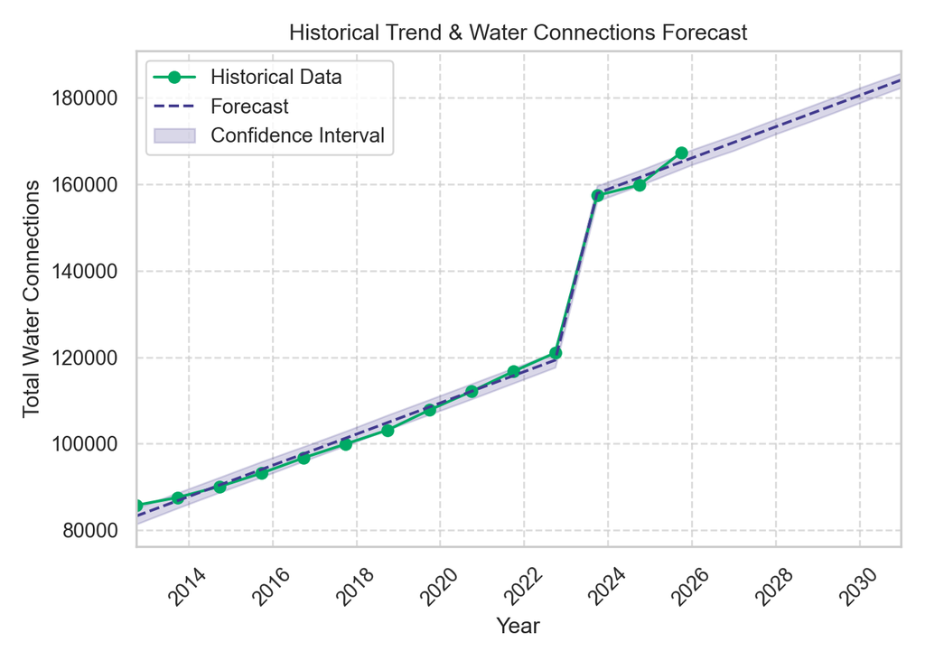

```python
plt.tight_layout()

plt.show()
```

```python
plt.close()
```

### Forecast Result

```python
forecast_dfs = [
    revenue_prophet_forecast[['ds', 'yhat']].rename(columns={'yhat': 'yhat_revenue'}),
    water_prophet_forecast[['ds', 'yhat']].rename(columns={'yhat': 'yhat_water'}),
    wastewater_prophet_forecast[['ds', 'yhat']].rename(columns={'yhat': 'yhat_wastewater'}),
    connections_prophet_forecast[['ds', 'yhat']].rename(columns={'yhat': 'yhat_connections'})
]

df_forecast = forecast_dfs[0]

for next_df in forecast_dfs[1:]:
    df_forecast = df_forecast.merge(next_df, on='ds', how='outer')

df_forecast = df_forecast.sort_values('ds', ascending=True).reset_index(drop=True)

df_forecast = df_forecast.dropna().reset_index(drop=True)

create_html_table(df_forecast)
```

| ds | yhat_revenue | yhat_water | yhat_wastewater | yhat_connections |
| --- | --- | --- | --- | --- |
| 2012-09-30 00:00:00 | 77409.4 | 704096 | 638800 | 83259.4 |
| 2013-09-30 00:00:00 | 79753.8 | 722111 | 651943 | 86862.2 |
| 2014-09-30 00:00:00 | 82098.3 | 740125 | 665087 | 90464.9 |
| 2015-09-30 00:00:00 | 91211.1 | 758295 | 685065 | 94067.6 |
| 2016-09-30 00:00:00 | 100349 | 776515 | 705097 | 97680.2 |
| 2017-09-30 00:00:00 | 109475 | 796490 | 726619 | 101285 |
| 2018-09-30 00:00:00 | 118600 | 816465 | 748140 | 104889 |
| 2019-09-30 00:00:00 | 127725 | 846911 | 769661 | 108499 |
| 2020-09-30 00:00:00 | 135607 | 877441 | 791242 | 112120 |
| 2021-09-30 00:00:00 | 143468 | 907937 | 829799 | 115732 |
| 2022-09-30 00:00:00 | 151329 | 938434 | 868356 | 119344 |
| 2023-09-30 00:00:00 | 206293 | 1.17128e+06 | 1.05888e+06 | 157907 |
| 2024-09-30 00:00:00 | 225705 | 1.20186e+06 | 1.09368e+06 | 161529 |
| 2025-09-30 00:00:00 | 245064 | 1.23236e+06 | 1.12838e+06 | 165141 |
| 2025-12-31 00:00:00 | 249944 | 1.24005e+06 | 1.13713e+06 | 166051 |
| 2026-12-31 00:00:00 | 269302 | 1.27054e+06 | 1.17184e+06 | 169663 |
| 2027-12-31 00:00:00 | 288661 | 1.30104e+06 | 1.20654e+06 | 173275 |
| 2028-12-31 00:00:00 | 308073 | 1.33162e+06 | 1.24134e+06 | 176897 |
| 2029-12-31 00:00:00 | 327432 | 1.36212e+06 | 1.27605e+06 | 180509 |
| 2030-12-31 00:00:00 | 346791 | 1.39261e+06 | 1.31075e+06 | 184121 |

## Position Forecasting

```python
forecast_mapping = {
    'yhat_wastewater': 'Wastewater (Mgal)',
    'yhat_revenue': 'Gross Revenue',
    'yhat_connections' : 'Total Customers/Connections - Water'
}


X_forecast = df_forecast[list(forecast_mapping.keys())].rename(columns=forecast_mapping)
X_forecast = X_forecast[best_ridge.feature_names_in_]

y_pred_mean, y_pred_std = best_ridge.predict(X_forecast, return_std=True)

#Calculate 95% conf interval
df_forecast['Predicted FTE'] = y_pred_mean
df_forecast['FTE_Lower_95'] = y_pred_mean - (1.96 * y_pred_std)
df_forecast['FTE_Upper_95'] = y_pred_mean + (1.96 * y_pred_std)

#Calculate 90% conf interval
df_forecast['Predicted FTE'] = y_pred_mean
df_forecast['FTE_Lower_90'] = y_pred_mean - (1.645 * y_pred_std)
df_forecast['FTE_Upper_90'] = y_pred_mean + (1.645 * y_pred_std)

#Calculate 80% conf interval
df_forecast['Predicted FTE'] = y_pred_mean
df_forecast['FTE_Lower_80'] = y_pred_mean - (1.282 * y_pred_std)
df_forecast['FTE_Upper_80'] = y_pred_mean + (1.282 * y_pred_std)


preview_cols = ['ds', 'Predicted FTE', 'FTE_Lower_95', 'FTE_Upper_95'] + list(forecast_mapping.keys())

create_html_table(df_forecast)
```

| ds | yhat_revenue | yhat_water | yhat_wastewater | yhat_connections | Predicted FTE | FTE_Lower_95 | FTE_Upper_95 | FTE_Lower_90 | FTE_Upper_90 | FTE_Lower_80 | FTE_Upper_80 |
| --- | --- | --- | --- | --- | --- | --- | --- | --- | --- | --- | --- |
| 2012-09-30 00:00:00 | 77409.4 | 704096 | 638800 | 83259.4 | 251.929 | 232.924 | 270.934 | 235.978 | 267.88 | 239.498 | 264.36 |
| 2013-09-30 00:00:00 | 79753.8 | 722111 | 651943 | 86862.2 | 263.261 | 244.278 | 282.243 | 247.329 | 279.193 | 250.844 | 275.677 |
| 2014-09-30 00:00:00 | 82098.3 | 740125 | 665087 | 90464.9 | 274.592 | 255.022 | 294.163 | 258.167 | 291.018 | 261.792 | 287.393 |
| 2015-09-30 00:00:00 | 91211.1 | 758295 | 685065 | 94067.6 | 294.253 | 275.5 | 313.006 | 278.514 | 309.992 | 281.987 | 306.519 |
| 2016-09-30 00:00:00 | 100349 | 776515 | 705097 | 97680.2 | 313.967 | 295.852 | 332.083 | 298.763 | 329.171 | 302.118 | 325.816 |
| 2017-09-30 00:00:00 | 109475 | 796490 | 726619 | 101285 | 334.368 | 316.747 | 351.988 | 319.579 | 349.157 | 322.842 | 345.893 |
| 2018-09-30 00:00:00 | 118600 | 816465 | 748140 | 104889 | 354.768 | 337.461 | 372.074 | 340.242 | 369.293 | 343.447 | 366.088 |
| 2019-09-30 00:00:00 | 127725 | 846911 | 769661 | 108499 | 375.173 | 357.989 | 392.357 | 360.751 | 389.595 | 363.933 | 386.413 |
| 2020-09-30 00:00:00 | 135607 | 877441 | 791242 | 112120 | 394.678 | 377.549 | 411.807 | 380.302 | 409.054 | 383.474 | 405.882 |
| 2021-09-30 00:00:00 | 143468 | 907937 | 829799 | 115732 | 422.17 | 405.271 | 439.068 | 407.987 | 436.353 | 411.117 | 433.223 |
| 2022-09-30 00:00:00 | 151329 | 938434 | 868356 | 119344 | 449.662 | 431.539 | 467.784 | 434.452 | 464.871 | 437.808 | 461.515 |
| 2023-09-30 00:00:00 | 206293 | 1.17128e+06 | 1.05888e+06 | 157907 | 616.995 | 596.905 | 637.085 | 600.134 | 633.857 | 603.855 | 630.136 |
| 2024-09-30 00:00:00 | 225705 | 1.20186e+06 | 1.09368e+06 | 161529 | 651.435 | 633.138 | 669.732 | 636.079 | 666.791 | 639.467 | 663.402 |
| 2025-09-30 00:00:00 | 245064 | 1.23236e+06 | 1.12838e+06 | 165141 | 685.78 | 665.394 | 706.167 | 668.67 | 702.89 | 672.446 | 699.115 |
| 2025-12-31 00:00:00 | 249944 | 1.24005e+06 | 1.13713e+06 | 166051 | 694.437 | 673 | 715.874 | 676.445 | 712.429 | 680.416 | 708.458 |
| 2026-12-31 00:00:00 | 269302 | 1.27054e+06 | 1.17184e+06 | 169663 | 728.782 | 701.814 | 755.751 | 706.148 | 751.416 | 711.143 | 746.422 |
| 2027-12-31 00:00:00 | 288661 | 1.30104e+06 | 1.20654e+06 | 173275 | 763.128 | 729.3 | 796.955 | 734.737 | 791.519 | 741.002 | 785.254 |
| 2028-12-31 00:00:00 | 308073 | 1.33162e+06 | 1.24134e+06 | 176897 | 797.567 | 756.186 | 838.948 | 762.837 | 832.298 | 770.501 | 824.634 |
| 2029-12-31 00:00:00 | 327432 | 1.36212e+06 | 1.27605e+06 | 180509 | 831.912 | 782.634 | 881.191 | 790.554 | 873.271 | 799.68 | 864.145 |
| 2030-12-31 00:00:00 | 346791 | 1.39261e+06 | 1.31075e+06 | 184121 | 866.258 | 808.867 | 923.648 | 818.091 | 914.425 | 828.72 | 903.796 |

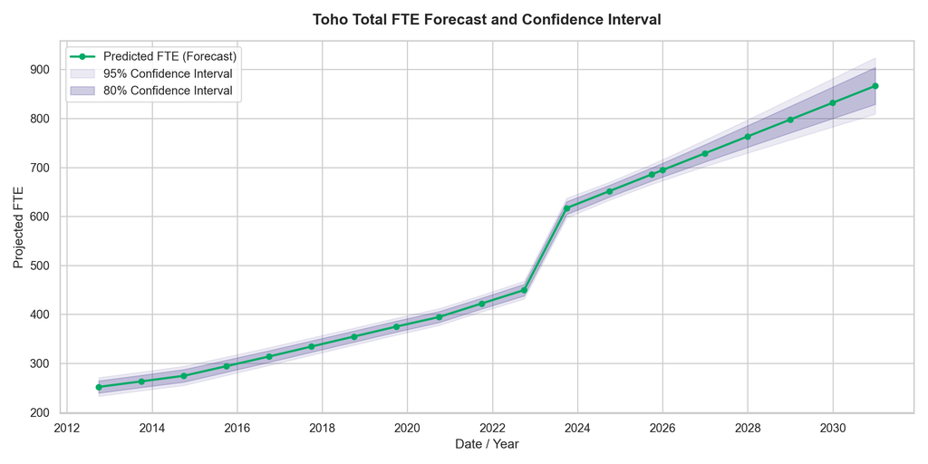

```python
df_forecast = df_forecast.sort_values('ds').reset_index(drop=True)

plt.figure(figsize=(12, 6))
sns.set_theme(style="whitegrid")

# Plot Predicted FTE
plt.plot(
    df_forecast['ds'],
    df_forecast['Predicted FTE'],
    label='Predicted FTE (Forecast)',
    color='#00AA65',
    linestyle='-',
    marker='o',
    linewidth=2,
    markersize=5
)

# 95% Confidence Interval
plt.fill_between(
    df_forecast['ds'],
    df_forecast['FTE_Lower_95'],
    df_forecast['FTE_Upper_95'],
    color='#413A8E',
    alpha=0.1,
    label='95% Confidence Interval'
)

# 80% Confidence Interval
plt.fill_between(
    df_forecast['ds'],
    df_forecast['FTE_Lower_80'],
    df_forecast['FTE_Upper_80'],
    color='#413A8E',
    alpha=0.25,
    label='80% Confidence Interval'
)

plt.title('Toho Total FTE Forecast and Confidence Interval', fontsize=14, fontweight='bold', pad=15)
plt.xlabel('Date / Year', fontsize=12)
plt.ylabel('Projected FTE', fontsize=12)

plt.legend(frameon=True, facecolor='white', loc='best')
plt.tight_layout()

plt.show()
```

```python
plt.close()
```

## Toho Departmental Growth Trend